# Final Project

Dwaipayan Chatterjee

9/12/2021

```r
# Uncomment below lines to install packages
# install.packages("ggplot2"") # Install ggplot2
# install.packages("reshape2") # Install reshape2
# install.packages("glmnet") # Install glmnet
# install.packages("plotmo")
library(ggplot2) # load ggplot
library(reshape2) # load reshape 2
library(glmnet) # Load glmnet
library(naniar)
library(plotmo)
library(ggridges)
library(glmnet)
library(plotmo)
# for plot_glmnet
```

```r
med_data<- read.csv("C:/Users/dwaip/Desktop/Mendoza Yr 2/Sem 3/ML/Final Project/heart_statlog_cleveland_hungary_final.csv")
```

```r
dim(med_data)
```

```
## [1] 1190   12
```

```r
summary(med_data)
```

```
##       age             sex         chest.pain.type  resting.bp.s
##  Min.   :28.00   Min.   :0.0000   Min.   :1.000   Min.   :  0.0
##  1st Qu.:47.00   1st Qu.:1.0000   1st Qu.:3.000   1st Qu.:120.0
##  Median :54.00   Median :1.0000   Median :4.000   Median :130.0
##  Mean   :53.72   Mean   :0.7639   Mean   :3.233   Mean   :132.2
##  3rd Qu.:60.00   3rd Qu.:1.0000   3rd Qu.:4.000   3rd Qu.:140.0
##  Max.   :77.00   Max.   :1.0000   Max.   :4.000   Max.   :200.0
##   cholesterol    fasting.blood.sugar  resting.ecg     max.heart.rate
##  Min.   :  0.0   Min.   :0.0000      Min.   :0.0000   Min.   : 60.0
##  1st Qu.:188.0   1st Qu.:0.0000      1st Qu.:0.0000   1st Qu.:121.0
##  Median :229.0   Median :0.0000      Median :0.0000   Median :140.5
##  Mean   :210.4   Mean   :0.2134      Mean   :0.6983   Mean   :139.7
##  3rd Qu.:269.8   3rd Qu.:0.0000      3rd Qu.:2.0000   3rd Qu.:160.0
##  Max.   :603.0   Max.   :1.0000      Max.   :2.0000   Max.   :202.0
##  exercise.angina     oldpeak           ST.slope         target
##  Min.   :0.0000   Min.   :-2.6000   Min.   :0.000   Min.   :0.0000
##  1st Qu.:0.0000   1st Qu.: 0.0000   1st Qu.:1.000   1st Qu.:0.0000
##  Median :0.0000   Median : 0.6000   Median :2.000   Median :1.0000
##  Mean   :0.3874   Mean   : 0.9228   Mean   :1.624   Mean   :0.5286
##  3rd Qu.:1.0000   3rd Qu.: 1.6000   3rd Qu.:2.000   3rd Qu.:1.0000
##  Max.   :1.0000   Max.   : 6.2000   Max.   :3.000   Max.   :1.0000
```

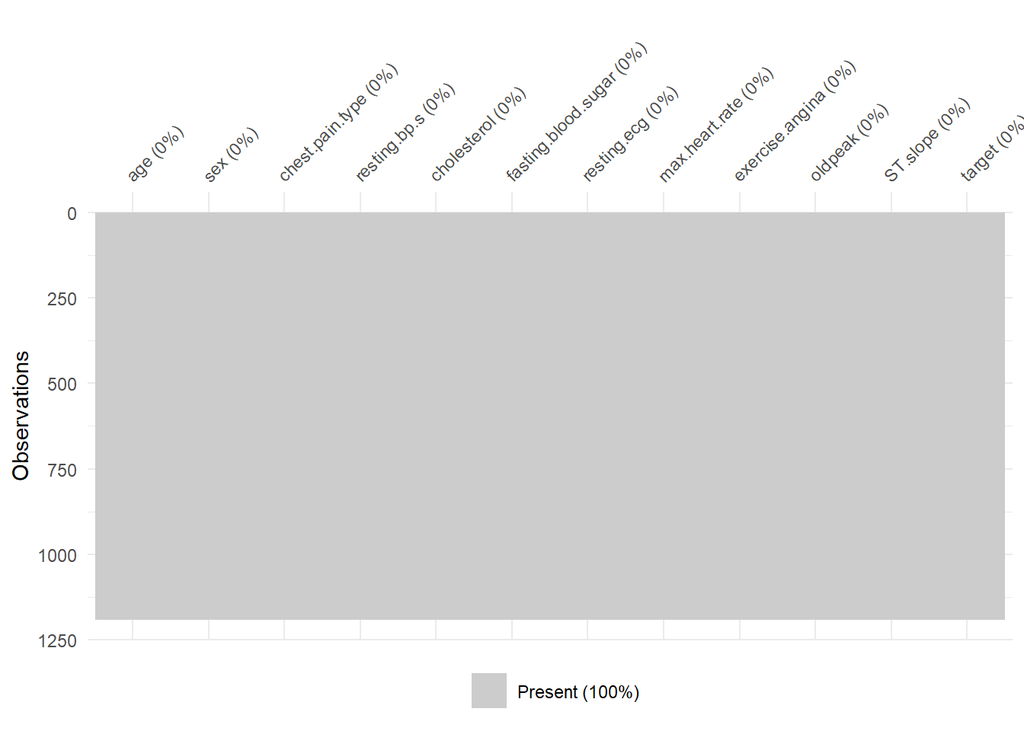

```r
vis_miss(med_data)
```

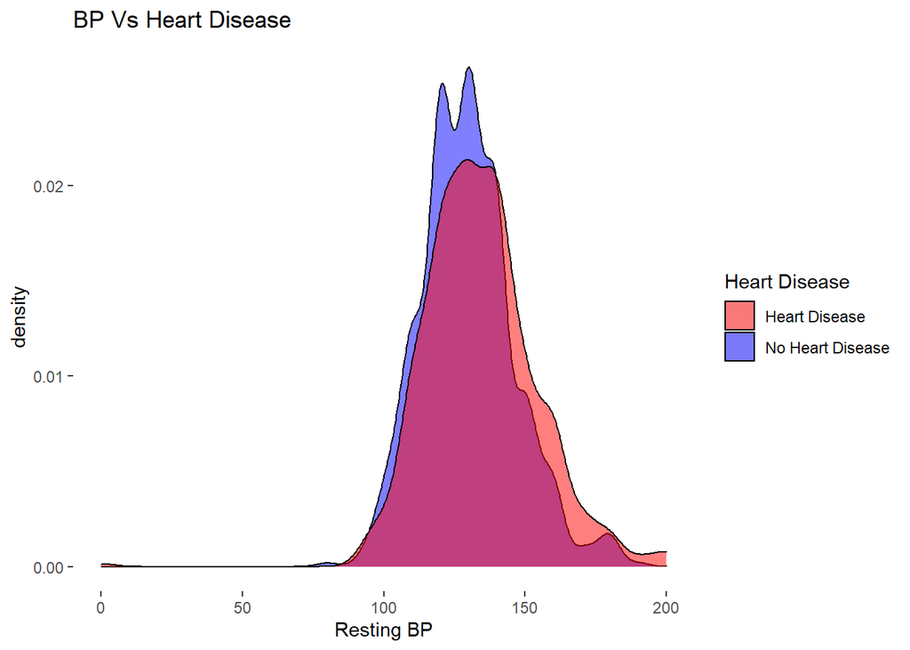

```r
g_1 <- ggplot(med_data, aes(x = resting.bp.s, fill = factor(target))) +
  geom_density(alpha = 0.5) +
    theme_set(theme_bw(base_size = 22) ) +
  theme(panel.grid.major = element_blank(),
        panel.grid.minor = element_blank(),
        panel.border = element_blank(),
        panel.background = element_blank()) +
  labs(x = "Resting BP", title = "BP Vs Heart Disease",
       fill = "Heart Disease") + # Set labels
  scale_fill_manual(values = c("1" = "red", "0" = "blue"),
                    labels = c("1" = "Heart Disease", "0" = "No Heart Disease"))
g_1
```

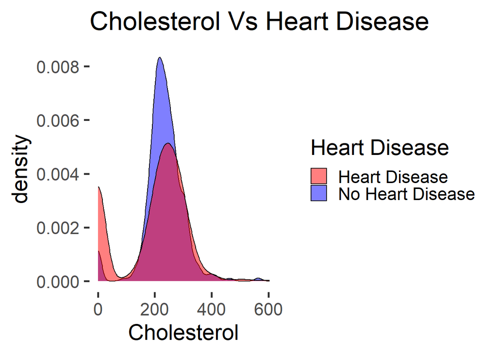

```r
g_2 <- ggplot(med_data, aes(x = cholesterol, fill = factor(target))) +
  geom_density(alpha = 0.5) +
    theme_set(theme_bw(base_size = 22) ) +
  theme(panel.grid.major = element_blank(),
        panel.grid.minor = element_blank(),
        panel.border = element_blank(),
        panel.background = element_blank()) +
  labs(x = "Cholesterol", title = "Cholesterol Vs Heart Disease",
       fill = "Heart Disease") + # Set labels
  scale_fill_manual(values = c("1" = "red", "0" = "blue"),
                    labels = c("1" = "Heart Disease", "0" = "No Heart Disease"))
g_2
```

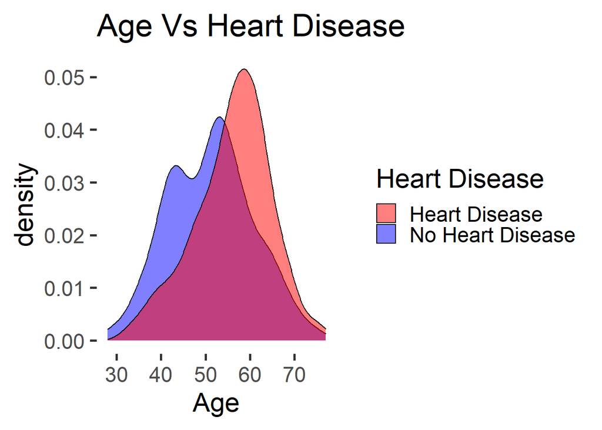

```r
g_3 <- ggplot(med_data, aes(x = age, fill = factor(target))) +
  geom_density(alpha = 0.5) +
    theme_set(theme_bw(base_size = 22) ) +
  theme(panel.grid.major = element_blank(),
        panel.grid.minor = element_blank(),
        panel.border = element_blank(),
        panel.background = element_blank()) +
  labs(x = "Age", title = "Age Vs Heart Disease",
       fill = "Heart Disease") + # Set labels
  scale_fill_manual(values = c("1" = "red", "0" = "blue"),
                    labels = c("1" = "Heart Disease", "0" = "No Heart Disease"))
g_3
```

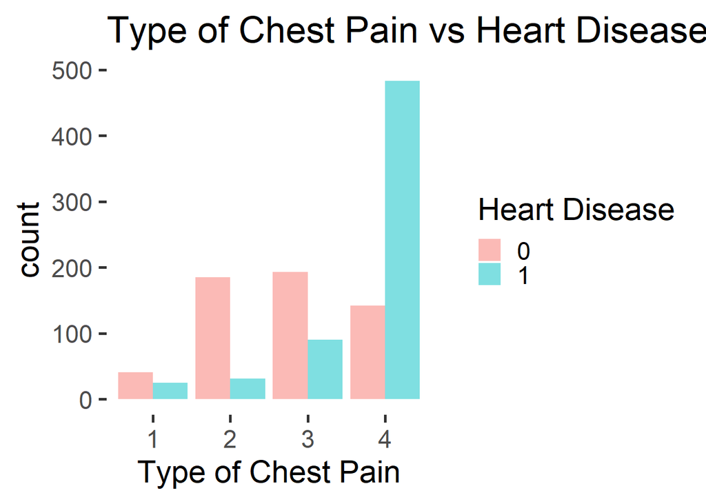

```r
g_4 <- ggplot(med_data, aes(x = factor(chest.pain.type), fill = factor(target))) + # Set x as mean texture and fill as diagnosis
  geom_bar(alpha = 0.5,position="dodge") + # Select density plot and set transperancy (alpha)
    theme_set(theme_bw(base_size = 22) ) + # Set theme and text size
  theme(panel.grid.major = element_blank(), # Remove grid
        panel.grid.minor = element_blank(), # Remove grid
        panel.border = element_blank(), # Remove grid
        panel.background = element_blank()) + # Remove grid
  labs(x = "Type of Chest Pain", title = "Type of Chest Pain vs Heart Disease",
       fill = "Heart Disease")  # Set labels

g_4
```

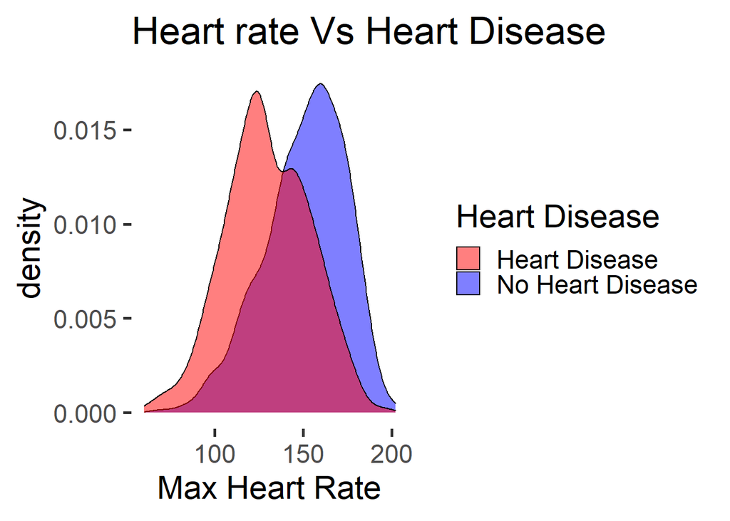

```r
g_5 <- ggplot(med_data, aes(x = max.heart.rate, fill = factor(target))) +
  geom_density(alpha = 0.5) +
    theme_set(theme_bw(base_size = 22) ) +
  theme(panel.grid.major = element_blank(),
        panel.grid.minor = element_blank(),
        panel.border = element_blank(),
        panel.background = element_blank()) +
  labs(x = "Max Heart Rate", title = "Heart rate Vs Heart Disease",
       fill = "Heart Disease") + # Set labels
  scale_fill_manual(values = c("1" = "red", "0" = "blue"),
                    labels = c("1" = "Heart Disease", "0" = "No Heart Disease"))
g_5
```

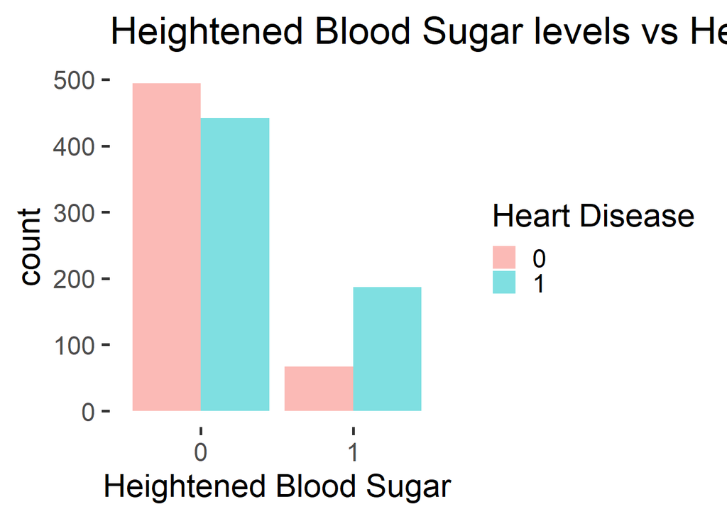

```r
g_6 <- ggplot(med_data, aes(x = factor(fasting.blood.sugar), fill = factor(target))) + # Set x as mean texture and fill as diagnosis
  geom_bar(alpha = 0.5,position="dodge") + # Select density plot and set transperancy (alpha)
    theme_set(theme_bw(base_size = 22) ) + # Set theme and text size
  theme(panel.grid.major = element_blank(), # Remove grid
        panel.grid.minor = element_blank(), # Remove grid
        panel.border = element_blank(), # Remove grid
        panel.background = element_blank()) + # Remove grid
  labs(x = "Heightened Blood Sugar", title = "Heightened Blood Sugar levels vs Heart Disease",
       fill = "Heart Disease")  # Set labels

g_6
```

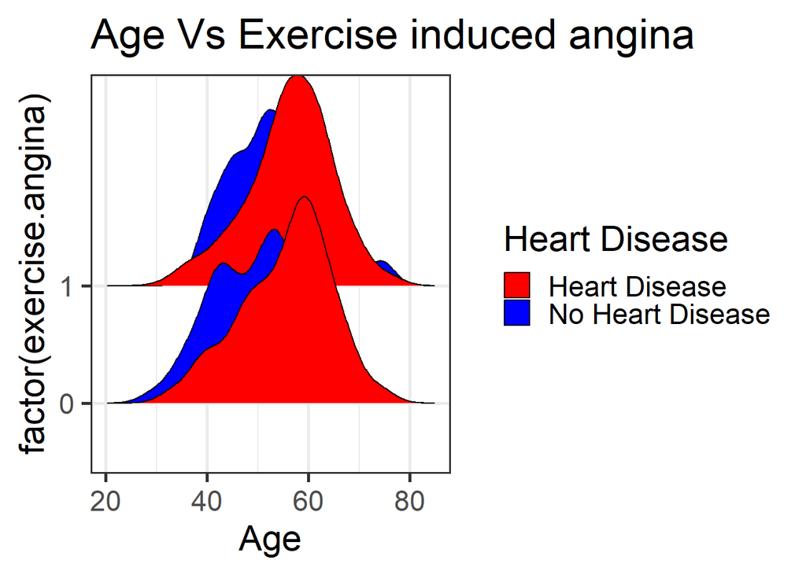

```r
g_7 <- ggplot(med_data,aes(x=age,y=factor(exercise.angina),fill=factor(target))) + geom_density_ridges() +labs(x = "Age", title = "Age Vs Exercise induced angina",
       fill = "Heart Disease") + # Set labels
  scale_fill_manual(values = c("1" = "red", "0" = "blue"),
                    labels = c("1" = "Heart Disease", "0" = "No Heart Disease"))

g_7
```

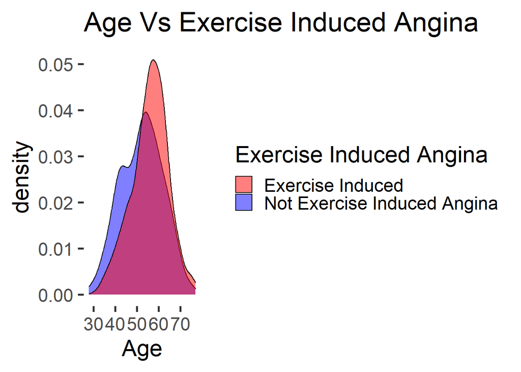

```r
g_8 <- ggplot(med_data, aes(x = age, fill = factor(exercise.angina))) +
  geom_density(alpha = 0.5) +
    theme_set(theme_bw(base_size = 22) ) +
  theme(panel.grid.major = element_blank(),
        panel.grid.minor = element_blank(),
        panel.border = element_blank(),
        panel.background = element_blank()) +
  labs(x = "Age", title = "Age Vs Exercise Induced Angina",
       fill = "Exercise Induced Angina") + # Set labels
  scale_fill_manual(values = c("1" = "red", "0" = "blue"),
                    labels = c("1" = "Exercise Induced", "0" = "Not Exercise Induced Angina"))
g_8
```

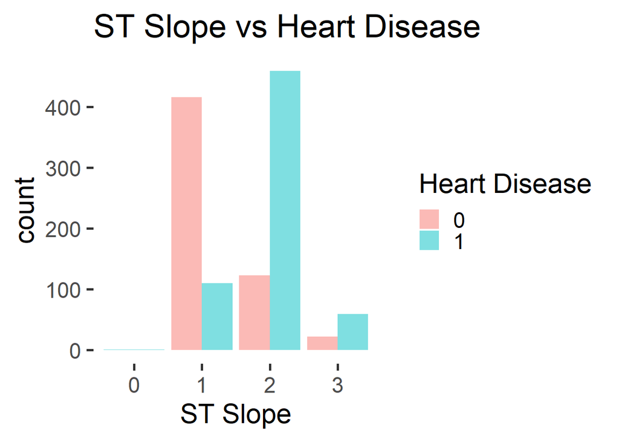

```r
g_9 <- ggplot(med_data, aes(x = factor(ST.slope), fill = factor(target))) + # Set x as mean texture and fill as diagnosis
  geom_bar(alpha = 0.5,position="dodge") + # Select density plot and set transperancy (alpha)
    theme_set(theme_bw(base_size = 22) ) + # Set theme and text size
  theme(panel.grid.major = element_blank(), # Remove grid
        panel.grid.minor = element_blank(), # Remove grid
        panel.border = element_blank(), # Remove grid
        panel.background = element_blank()) + # Remove grid
  labs(x = "ST Slope", title = "ST Slope vs Heart Disease",
       fill = "Heart Disease")  # Set labels

g_9
```

Splitting data into Train and Test

```r
library(splitstackshape)
set.seed(123456)
split_dat <- stratified(med_data, # Set dataset
                         group = "target",
                         size = 0.2,  # Set size of test set
                         bothSets = TRUE ) # Return both training and test sets
 # Extract train data
 train_dat <- split_dat[[2]]
 # Extract test data
 test_dat <- split_dat[[1]]
```

#Logistic Regression

```r
fit_1 <- glm(target ~ age, # Set formula
             family=binomial(link='logit'), # Set logistic regression
             data=  train_dat) # Set dataset
summary(fit_1)
```

```
##
## Call:
## glm(formula = target ~ age, family = binomial(link = "logit"),
##     data = train_dat)
##
## Deviance Residuals:
##     Min       1Q   Median       3Q      Max
## -1.7301  -1.1680   0.8299   1.0810   1.6361
##
## Coefficients:
##              Estimate Std. Error z value Pr(>|z|)
## (Intercept) -2.603023   0.402699  -6.464 1.02e-10 ***
## age          0.050607   0.007407   6.832 8.38e-12 ***
## ---
## Signif. codes:  0 '***' 0.001 '**' 0.01 '*' 0.05 '.' 0.1 ' ' 1
##
## (Dispersion parameter for binomial family taken to be 1)
##
##     Null deviance: 1316.7  on 951  degrees of freedom
## Residual deviance: 1266.9  on 950  degrees of freedom
## AIC: 1270.9
##
## Number of Fisher Scoring iterations: 4
```

```r
fit_2 <- glm(target ~ sex, # Set formula
             family=binomial(link='logit'), # Set logistic regression
             data=  train_dat) # Set dataset
summary(fit_2)
```

```
##
## Call:
## glm(formula = target ~ sex, family = binomial(link = "logit"),
##     data = train_dat)
##
## Deviance Residuals:
##     Min       1Q   Median       3Q      Max
## -1.3878  -1.3878   0.9807   0.9807   1.6783
##
## Coefficients:
##             Estimate Std. Error z value Pr(>|z|)
## (Intercept)  -1.1279     0.1537  -7.336 2.19e-13 ***
## sex           1.6101     0.1717   9.375  < 2e-16 ***
## ---
## Signif. codes:  0 '***' 0.001 '**' 0.01 '*' 0.05 '.' 0.1 ' ' 1
##
## (Dispersion parameter for binomial family taken to be 1)
##
##     Null deviance: 1316.7  on 951  degrees of freedom
## Residual deviance: 1216.2  on 950  degrees of freedom
## AIC: 1220.2
##
## Number of Fisher Scoring iterations: 4
```

```r
fit_3 <- glm(target ~ chest.pain.type, # Set formula
             family=binomial(link='logit'), # Set logistic regression
             data=  train_dat) # Set dataset
summary(fit_3)
```

```
##
## Call:
## glm(formula = target ~ chest.pain.type, family = binomial(link = "logit"),
##     data = train_dat)
##
## Deviance Residuals:
##     Min       1Q   Median       3Q      Max
## -1.6046  -1.0939   0.8036   0.8036   2.2824
##
## Coefficients:
##                 Estimate Std. Error z value Pr(>|z|)
## (Intercept)     -3.69187    0.31454  -11.74   <2e-16 ***
## chest.pain.type  1.16410    0.09143   12.73   <2e-16 ***
## ---
## Signif. codes:  0 '***' 0.001 '**' 0.01 '*' 0.05 '.' 0.1 ' ' 1
##
## (Dispersion parameter for binomial family taken to be 1)
##
##     Null deviance: 1316.7  on 951  degrees of freedom
## Residual deviance: 1102.8  on 950  degrees of freedom
## AIC: 1106.8
##
## Number of Fisher Scoring iterations: 4
```

```r
fit_4 <- glm(target ~ resting.bp.s, # Set formula
             family=binomial(link='logit'), # Set logistic regression
             data=  train_dat) # Set dataset
summary(fit_4)
```

```
##
## Call:
## glm(formula = target ~ resting.bp.s, family = binomial(link = "logit"),
##     data = train_dat)
##
## Deviance Residuals:
##     Min       1Q   Median       3Q      Max
## -1.4949  -1.2162   0.9373   1.1392   1.8661
##
## Coefficients:
##               Estimate Std. Error z value Pr(>|z|)
## (Intercept)  -1.548355   0.487648  -3.175 0.001498 **
## resting.bp.s  0.012608   0.003671   3.435 0.000593 ***
## ---
## Signif. codes:  0 '***' 0.001 '**' 0.01 '*' 0.05 '.' 0.1 ' ' 1
##
## (Dispersion parameter for binomial family taken to be 1)
##
##     Null deviance: 1316.7  on 951  degrees of freedom
## Residual deviance: 1304.5  on 950  degrees of freedom
## AIC: 1308.5
##
## Number of Fisher Scoring iterations: 4
```

```r
fit_5 <- glm(target ~ cholesterol, # Set formula
             family=binomial(link='logit'), # Set logistic regression
             data=  train_dat) # Set dataset
summary(fit_5)
```

```
##
## Call:
## glm(formula = target ~ cholesterol, family = binomial(link = "logit"),
##     data = train_dat)
##
## Deviance Residuals:
##     Min       1Q   Median       3Q      Max
## -1.6338  -1.1860   0.7817   1.1615   1.8759
##
## Coefficients:
##               Estimate Std. Error z value Pr(>|z|)
## (Intercept)  1.0291520  0.1651668   6.231 4.64e-10 ***
## cholesterol -0.0043113  0.0007016  -6.145 8.02e-10 ***
## ---
## Signif. codes:  0 '***' 0.001 '**' 0.01 '*' 0.05 '.' 0.1 ' ' 1
##
## (Dispersion parameter for binomial family taken to be 1)
##
##     Null deviance: 1316.7  on 951  degrees of freedom
## Residual deviance: 1275.2  on 950  degrees of freedom
## AIC: 1279.2
##
## Number of Fisher Scoring iterations: 4
```

```r
fit_6 <- glm(target ~ fasting.blood.sugar, # Set formula
             family=binomial(link='logit'), # Set logistic regression
             data=  train_dat) # Set dataset
summary(fit_6)
```

```
##
## Call:
## glm(formula = target ~ fasting.blood.sugar, family = binomial(link = "logit"),
##     data = train_dat)
##
## Deviance Residuals:
##     Min       1Q   Median       3Q      Max
## -1.6565  -1.1219   0.7648   1.2340   1.2340
##
## Coefficients:
##                     Estimate Std. Error z value Pr(>|z|)
## (Intercept)         -0.13209    0.07353  -1.796   0.0724 .
## fasting.blood.sugar  1.21165    0.17517   6.917 4.62e-12 ***
## ---
## Signif. codes:  0 '***' 0.001 '**' 0.01 '*' 0.05 '.' 0.1 ' ' 1
##
## (Dispersion parameter for binomial family taken to be 1)
##
##     Null deviance: 1316.7  on 951  degrees of freedom
## Residual deviance: 1263.5  on 950  degrees of freedom
## AIC: 1267.5
##
## Number of Fisher Scoring iterations: 4
```

```r
fit_7 <- glm(target ~ resting.ecg, # Set formula
             family=binomial(link='logit'), # Set logistic regression
             data=  train_dat) # Set dataset
summary(fit_7)
```

```
##
## Call:
## glm(formula = target ~ resting.ecg, family = binomial(link = "logit"),
##     data = train_dat)
##
## Deviance Residuals:
##    Min      1Q  Median      3Q     Max
## -1.322  -1.177   1.040   1.177   1.177
##
## Coefficients:
##              Estimate Std. Error z value Pr(>|z|)
## (Intercept) 8.922e-05  8.274e-02   0.001   0.9991
## resting.ecg 1.663e-01  7.545e-02   2.204   0.0275 *
## ---
## Signif. codes:  0 '***' 0.001 '**' 0.01 '*' 0.05 '.' 0.1 ' ' 1
##
## (Dispersion parameter for binomial family taken to be 1)
##
##     Null deviance: 1316.7  on 951  degrees of freedom
## Residual deviance: 1311.8  on 950  degrees of freedom
## AIC: 1315.8
##
## Number of Fisher Scoring iterations: 3
```

```r
fit_8 <- glm(target ~ max.heart.rate, # Set formula
             family=binomial(link='logit'), # Set logistic regression
             data=  train_dat) # Set dataset
summary(fit_8)
```

```
##
## Call:
## glm(formula = target ~ max.heart.rate, family = binomial(link = "logit"),
##     data = train_dat)
##
## Deviance Residuals:
##     Min       1Q   Median       3Q      Max
## -2.4852  -0.9634   0.4926   0.9476   2.0913
##
## Coefficients:
##                 Estimate Std. Error z value Pr(>|z|)
## (Intercept)     5.839240   0.474109   12.32   <2e-16 ***
## max.heart.rate -0.040548   0.003295  -12.30   <2e-16 ***
## ---
## Signif. codes:  0 '***' 0.001 '**' 0.01 '*' 0.05 '.' 0.1 ' ' 1
##
## (Dispersion parameter for binomial family taken to be 1)
##
##     Null deviance: 1316.7  on 951  degrees of freedom
## Residual deviance: 1122.1  on 950  degrees of freedom
## AIC: 1126.1
##
## Number of Fisher Scoring iterations: 3
```

```r
fit_9 <- glm(target ~ exercise.angina, # Set formula
             family=binomial(link='logit'), # Set logistic regression
             data=  train_dat) # Set dataset
summary(fit_9)
```

```
##
## Call:
## glm(formula = target ~ exercise.angina, family = binomial(link = "logit"),
##     data = train_dat)
##
## Deviance Residuals:
##     Min       1Q   Median       3Q      Max
## -1.8771  -0.9202   0.6139   0.6139   1.4586
##
## Coefficients:
##                 Estimate Std. Error z value Pr(>|z|)
## (Intercept)     -0.64030    0.08652  -7.401 1.36e-13 ***
## exercise.angina  2.21361    0.16419  13.482  < 2e-16 ***
## ---
## Signif. codes:  0 '***' 0.001 '**' 0.01 '*' 0.05 '.' 0.1 ' ' 1
##
## (Dispersion parameter for binomial family taken to be 1)
##
##     Null deviance: 1316.7  on 951  degrees of freedom
## Residual deviance: 1092.8  on 950  degrees of freedom
## AIC: 1096.8
##
## Number of Fisher Scoring iterations: 4
```

```r
fit_10 <- glm(target ~ oldpeak, # Set formula
             family=binomial(link='logit'), # Set logistic regression
             data= train_dat) # Set dataset
summary(fit_10)
```

```
##
## Call:
## glm(formula = target ~ oldpeak, family = binomial(link = "logit"),
##     data = train_dat)
##
## Deviance Residuals:
##     Min       1Q   Median       3Q      Max
## -2.5553  -0.9131   0.3999   0.9930   2.4941
##
## Coefficients:
##             Estimate Std. Error z value Pr(>|z|)
## (Intercept) -0.65940    0.09316  -7.078 1.46e-12 ***
## oldpeak      0.92505    0.08239  11.228  < 2e-16 ***
## ---
## Signif. codes:  0 '***' 0.001 '**' 0.01 '*' 0.05 '.' 0.1 ' ' 1
##
## (Dispersion parameter for binomial family taken to be 1)
##
##     Null deviance: 1316.7  on 951  degrees of freedom
## Residual deviance: 1149.6  on 950  degrees of freedom
## AIC: 1153.6
##
## Number of Fisher Scoring iterations: 4
```

```r
fit_11 <- glm(target ~ ST.slope, # Set formula
             family=binomial(link='logit'), # Set logistic regression
             data= train_dat) # Set dataset
summary(fit_11)
```

```
##
## Call:
## glm(formula = target ~ ST.slope, family = binomial(link = "logit"),
##     data = train_dat)
##
## Deviance Residuals:
##     Min       1Q   Median       3Q      Max
## -2.5093  -0.7472   0.2962   0.7964   2.5651
##
## Coefficients:
##             Estimate Std. Error z value Pr(>|z|)
## (Intercept)  -3.2519     0.2396  -13.57   <2e-16 ***
## ST.slope      2.1188     0.1450   14.61   <2e-16 ***
## ---
## Signif. codes:  0 '***' 0.001 '**' 0.01 '*' 0.05 '.' 0.1 ' ' 1
##
## (Dispersion parameter for binomial family taken to be 1)
##
##     Null deviance: 1316.7  on 951  degrees of freedom
## Residual deviance: 1038.2  on 950  degrees of freedom
## AIC: 1042.2
##
## Number of Fisher Scoring iterations: 4
```

We will start with ST.slope since it has Lowest AIC variable and add variables and interactions to it.

```r
fit_12 <- glm(target ~ ST.slope*fasting.blood.sugar, # Set formula
             family=binomial(link='logit'), # Set logistic regression
             data= train_dat) # Set dataset
summary(fit_12)
```

```
##
## Call:
## glm(formula = target ~ ST.slope * fasting.blood.sugar, family = binomial(link = "logit"),
##     data = train_dat)
##
## Deviance Residuals:
##     Min       1Q   Median       3Q      Max
## -2.5202  -0.6519   0.3343   0.8450   1.8183
##
## Coefficients:
##                              Estimate Std. Error z value Pr(>|z|)
## (Intercept)                   -3.7275     0.2841 -13.123  < 2e-16 ***
## ST.slope                       2.2869     0.1704  13.419  < 2e-16 ***
## fasting.blood.sugar            2.5060     0.5730   4.373 1.22e-05 ***
## ST.slope:fasting.blood.sugar  -0.9276     0.3407  -2.722  0.00648 **
## ---
## Signif. codes:  0 '***' 0.001 '**' 0.01 '*' 0.05 '.' 0.1 ' ' 1
##
## (Dispersion parameter for binomial family taken to be 1)
##
##     Null deviance: 1316.7  on 951  degrees of freedom
## Residual deviance: 1001.4  on 948  degrees of freedom
## AIC: 1009.4
##
## Number of Fisher Scoring iterations: 4
```

```r
fit_13 <- glm(target ~ ST.slope*fasting.blood.sugar+exercise.angina, # Set formula
             family=binomial(link='logit'), # Set logistic regression
             data= train_dat) # Set dataset
summary(fit_13)
```

```
##
## Call:
## glm(formula = target ~ ST.slope * fasting.blood.sugar + exercise.angina,
##     family = binomial(link = "logit"), data = train_dat)
##
## Deviance Residuals:
##     Min       1Q   Median       3Q      Max
## -2.7415  -0.5490   0.2267   0.5539   1.9834
##
## Coefficients:
##                              Estimate Std. Error z value Pr(>|z|)
## (Intercept)                   -3.6674     0.2959 -12.395  < 2e-16 ***
## ST.slope                       1.8512     0.1771  10.454  < 2e-16 ***
## fasting.blood.sugar            2.2586     0.5934   3.806 0.000141 ***
## exercise.angina                1.7621     0.1826   9.649  < 2e-16 ***
## ST.slope:fasting.blood.sugar  -0.7242     0.3490  -2.075 0.037983 *
## ---
## Signif. codes:  0 '***' 0.001 '**' 0.01 '*' 0.05 '.' 0.1 ' ' 1
##
## (Dispersion parameter for binomial family taken to be 1)
##
##     Null deviance: 1316.69  on 951  degrees of freedom
## Residual deviance:  899.87  on 947  degrees of freedom
## AIC: 909.87
##
## Number of Fisher Scoring iterations: 4
```

Next adding in the interaction of chest pain type which has one of the lowest AICs with Cholesterol. Adding this interaction since research suggests cholesterol clogs up our arteries and hence should lead to chest pain. Trying interaction with blood pressure increased the AIC

```r
fit_14 <- glm(target ~ ST.slope*fasting.blood.sugar+exercise.angina+chest.pain.type*cholesterol, # Set formula
             family=binomial(link='logit'), # Set logistic regression
             data= train_dat) # Set dataset
summary(fit_14)
```

```
##
## Call:
## glm(formula = target ~ ST.slope * fasting.blood.sugar + exercise.angina +
##     chest.pain.type * cholesterol, family = binomial(link = "logit"),
##     data = train_dat)
##
## Deviance Residuals:
##     Min       1Q   Median       3Q      Max
## -2.6753  -0.6006   0.2248   0.5560   2.7622
##
## Coefficients:
##                                Estimate Std. Error z value Pr(>|z|)
## (Intercept)                  -4.8860161  0.9266030  -5.273 1.34e-07 ***
## ST.slope                      1.8289810  0.1835695   9.963  < 2e-16 ***
## fasting.blood.sugar           2.2302353  0.6403631   3.483 0.000496 ***
## exercise.angina               1.3570257  0.1982590   6.845 7.66e-12 ***
## chest.pain.type               0.7078592  0.2512995   2.817 0.004851 **
## cholesterol                  -0.0058145  0.0038223  -1.521 0.128207
## ST.slope:fasting.blood.sugar -0.7735583  0.3721557  -2.079 0.037655 *
## chest.pain.type:cholesterol   0.0005274  0.0010862   0.486 0.627311
## ---
## Signif. codes:  0 '***' 0.001 '**' 0.01 '*' 0.05 '.' 0.1 ' ' 1
##
## (Dispersion parameter for binomial family taken to be 1)
##
##     Null deviance: 1316.7  on 951  degrees of freedom
## Residual deviance:  803.6  on 944  degrees of freedom
## AIC: 819.6
##
## Number of Fisher Scoring iterations: 5
```

Significant reduction in AIC. Trying different combinations from here on

```r
fit_15 <- glm(target ~ ST.slope*fasting.blood.sugar+exercise.angina+chest.pain.type*cholesterol+oldpeak, # Set formula
             family=binomial(link='logit'), # Set logistic regression
             data= train_dat) # Set dataset
summary(fit_15)
```

```
##
## Call:
## glm(formula = target ~ ST.slope * fasting.blood.sugar + exercise.angina +
##     chest.pain.type * cholesterol + oldpeak, family = binomial(link = "logit"),
##     data = train_dat)
##
## Deviance Residuals:
##     Min       1Q   Median       3Q      Max
## -2.7242  -0.5971   0.1912   0.5770   2.7992
##
## Coefficients:
##                               Estimate Std. Error z value Pr(>|z|)
## (Intercept)                  -4.610780   0.933059  -4.942 7.75e-07 ***
## ST.slope                      1.499505   0.202255   7.414 1.23e-13 ***
## fasting.blood.sugar           2.000134   0.651742   3.069 0.002148 **
## exercise.angina               1.242200   0.202137   6.145 7.98e-10 ***
## chest.pain.type               0.714965   0.252285   2.834 0.004597 **
## cholesterol                  -0.005984   0.003848  -1.555 0.119896
## oldpeak                       0.377876   0.103056   3.667 0.000246 ***
## ST.slope:fasting.blood.sugar -0.602049   0.378984  -1.589 0.112153
## chest.pain.type:cholesterol   0.000485   0.001092   0.444 0.656967
## ---
## Signif. codes:  0 '***' 0.001 '**' 0.01 '*' 0.05 '.' 0.1 ' ' 1
##
## (Dispersion parameter for binomial family taken to be 1)
##
##     Null deviance: 1316.69  on 951  degrees of freedom
## Residual deviance:  789.74  on 943  degrees of freedom
## AIC: 807.74
##
## Number of Fisher Scoring iterations: 5
```

```r
fit_16 <- glm(target ~ ST.slope*fasting.blood.sugar+exercise.angina+chest.pain.type*cholesterol+oldpeak*sex, # Set formula
             family=binomial(link='logit'), # Set logistic regression
             data= train_dat) # Set dataset
summary(fit_16)
```

```
##
## Call:
## glm(formula = target ~ ST.slope * fasting.blood.sugar + exercise.angina +
##     chest.pain.type * cholesterol + oldpeak * sex, family = binomial(link = "logit"),
##     data = train_dat)
##
## Deviance Residuals:
##     Min       1Q   Median       3Q      Max
## -2.7902  -0.5869   0.1982   0.5541   2.6524
##
## Coefficients:
##                                Estimate Std. Error z value Pr(>|z|)
## (Intercept)                  -6.0145505  1.0153131  -5.924 3.15e-09 ***
## ST.slope                      1.5888360  0.2118080   7.501 6.32e-14 ***
## fasting.blood.sugar           2.0217144  0.6621601   3.053  0.00226 **
## exercise.angina               1.1525675  0.2086453   5.524 3.31e-08 ***
## chest.pain.type               0.7138515  0.2579078   2.768  0.00564 **
## cholesterol                  -0.0048825  0.0039871  -1.225  0.22074
## oldpeak                       0.4039973  0.2103908   1.920  0.05483 .
## sex                           1.4305681  0.3209826   4.457 8.32e-06 ***
## ST.slope:fasting.blood.sugar -0.6998493  0.3844046  -1.821  0.06867 .
## chest.pain.type:cholesterol   0.0004645  0.0011229   0.414  0.67914
## oldpeak:sex                  -0.0555979  0.2314392  -0.240  0.81015
## ---
## Signif. codes:  0 '***' 0.001 '**' 0.01 '*' 0.05 '.' 0.1 ' ' 1
##
## (Dispersion parameter for binomial family taken to be 1)
##
##     Null deviance: 1316.69  on 951  degrees of freedom
## Residual deviance:  752.34  on 941  degrees of freedom
## AIC: 774.34
##
## Number of Fisher Scoring iterations: 5
```

```r
fit_16 <- glm(target ~ ST.slope*fasting.blood.sugar+exercise.angina*max.heart.rate+chest.pain.type*cholesterol+oldpeak*sex+age, # Set formula
             family=binomial(link='logit'), # Set logistic regression
             data= train_dat) # Set dataset
summary(fit_16)
```

```
##
## Call:
## glm(formula = target ~ ST.slope * fasting.blood.sugar + exercise.angina *
##     max.heart.rate + chest.pain.type * cholesterol + oldpeak *
##     sex + age, family = binomial(link = "logit"), data = train_dat)
##
## Deviance Residuals:
##     Min       1Q   Median       3Q      Max
## -2.9744  -0.5489   0.1877   0.5404   2.4718
##
## Coefficients:
##                                  Estimate Std. Error z value Pr(>|z|)
## (Intercept)                    -5.0340982  1.4870994  -3.385 0.000711 ***
## ST.slope                        1.4003712  0.2175001   6.438 1.21e-10 ***
## fasting.blood.sugar             1.8307265  0.6521828   2.807 0.004999 **
## exercise.angina                 1.7646025  1.2842814   1.374 0.169442
## max.heart.rate                 -0.0114157  0.0050364  -2.267 0.023413 *
## chest.pain.type                 0.7067806  0.2596976   2.722 0.006498 **
## cholesterol                    -0.0036758  0.0039984  -0.919 0.357931
## oldpeak                         0.3878852  0.2098186   1.849 0.064506 .
## sex                             1.4188372  0.3231953   4.390 1.13e-05 ***
## age                             0.0167789  0.0110875   1.513 0.130199
## ST.slope:fasting.blood.sugar   -0.6161102  0.3786478  -1.627 0.103709
## exercise.angina:max.heart.rate -0.0054922  0.0091415  -0.601 0.547969
## chest.pain.type:cholesterol     0.0002739  0.0011273   0.243 0.808049
## oldpeak:sex                    -0.0445939  0.2304605  -0.193 0.846568
## ---
## Signif. codes:  0 '***' 0.001 '**' 0.01 '*' 0.05 '.' 0.1 ' ' 1
##
## (Dispersion parameter for binomial family taken to be 1)
##
##     Null deviance: 1316.69  on 951  degrees of freedom
## Residual deviance:  736.39  on 938  degrees of freedom
## AIC: 764.39
##
## Number of Fisher Scoring iterations: 5
```

```r
fit_17 <- glm(target ~ ST.slope*fasting.blood.sugar+exercise.angina*age+chest.pain.type*cholesterol+oldpeak*sex, # Set formula
             family=binomial(link='logit'), # Set logistic regression
             data= train_dat) # Set dataset
summary(fit_17)
```

```
##
## Call:
## glm(formula = target ~ ST.slope * fasting.blood.sugar + exercise.angina *
##     age + chest.pain.type * cholesterol + oldpeak * sex, family = binomial(link = "logit"),
##     data = train_dat)
##
## Deviance Residuals:
##     Min       1Q   Median       3Q      Max
## -2.9362  -0.5491   0.1988   0.5652   2.5737
##
## Coefficients:
##                                Estimate Std. Error z value Pr(>|z|)
## (Intercept)                  -7.4151570  1.2318036  -6.020 1.75e-09 ***
## ST.slope                      1.5634711  0.2144980   7.289 3.12e-13 ***
## fasting.blood.sugar           1.9433401  0.6578790   2.954  0.00314 **
## exercise.angina               1.0087492  1.2803111   0.788  0.43076
## age                           0.0259238  0.0124313   2.085  0.03704 *
## chest.pain.type               0.7329760  0.2590636   2.829  0.00466 **
## cholesterol                  -0.0046431  0.0039909  -1.163  0.24466
## oldpeak                       0.3648388  0.2098675   1.738  0.08214 .
## sex                           1.4749143  0.3239080   4.553 5.28e-06 ***
## ST.slope:fasting.blood.sugar -0.7032230  0.3810846  -1.845  0.06499 .
## exercise.angina:age           0.0020171  0.0231303   0.087  0.93051
## chest.pain.type:cholesterol   0.0003916  0.0011251   0.348  0.72782
## oldpeak:sex                  -0.0493378  0.2300944  -0.214  0.83022
## ---
## Signif. codes:  0 '***' 0.001 '**' 0.01 '*' 0.05 '.' 0.1 ' ' 1
##
## (Dispersion parameter for binomial family taken to be 1)
##
##     Null deviance: 1316.69  on 951  degrees of freedom
## Residual deviance:  745.88  on 939  degrees of freedom
## AIC: 771.88
##
## Number of Fisher Scoring iterations: 5
```

```r
fit_18 <- glm(target ~ ST.slope*fasting.blood.sugar+exercise.angina*age+chest.pain.type*cholesterol+oldpeak*sex+max.heart.rate, # Set formula
             family=binomial(link='logit'), # Set logistic regression
             data= train_dat) # Set dataset
summary(fit_18)
```

```
##
## Call:
## glm(formula = target ~ ST.slope * fasting.blood.sugar + exercise.angina *
##     age + chest.pain.type * cholesterol + oldpeak * sex + max.heart.rate,
##     family = binomial(link = "logit"), data = train_dat)
##
## Deviance Residuals:
##     Min       1Q   Median       3Q      Max
## -2.9817  -0.5447   0.1946   0.5357   2.5075
##
## Coefficients:
##                                Estimate Std. Error z value Pr(>|z|)
## (Intercept)                  -4.6667164  1.5035487  -3.104  0.00191 **
## ST.slope                      1.4167666  0.2175302   6.513 7.37e-11 ***
## fasting.blood.sugar           1.8612140  0.6534695   2.848  0.00440 **
## exercise.angina               0.5324902  1.2959537   0.411  0.68116
## age                           0.0134513  0.0130010   1.035  0.30084
## chest.pain.type               0.7146543  0.2593581   2.755  0.00586 **
## cholesterol                  -0.0035268  0.0039920  -0.883  0.37699
## oldpeak                       0.3912320  0.2099368   1.864  0.06238 .
## sex                           1.4264590  0.3233500   4.412 1.03e-05 ***
## max.heart.rate               -0.0131498  0.0043469  -3.025  0.00249 **
## ST.slope:fasting.blood.sugar -0.6346676  0.3792829  -1.673  0.09426 .
## exercise.angina:age           0.0086131  0.0233389   0.369  0.71210
## chest.pain.type:cholesterol   0.0002306  0.0011249   0.205  0.83758
## oldpeak:sex                  -0.0410942  0.2301496  -0.179  0.85829
## ---
## Signif. codes:  0 '***' 0.001 '**' 0.01 '*' 0.05 '.' 0.1 ' ' 1
##
## (Dispersion parameter for binomial family taken to be 1)
##
##     Null deviance: 1316.69  on 951  degrees of freedom
## Residual deviance:  736.62  on 938  degrees of freedom
## AIC: 764.62
##
## Number of Fisher Scoring iterations: 5
```

```r
fit_19 <- glm(target ~ ST.slope*fasting.blood.sugar+exercise.angina*age+chest.pain.type*cholesterol+oldpeak*sex+max.heart.rate+resting.ecg, # Set formula
             family=binomial(link='logit'), # Set logistic regression
             data= train_dat) # Set dataset
summary(fit_19)
```

```
##
## Call:
## glm(formula = target ~ ST.slope * fasting.blood.sugar + exercise.angina *
##     age + chest.pain.type * cholesterol + oldpeak * sex + max.heart.rate +
##     resting.ecg, family = binomial(link = "logit"), data = train_dat)
##
## Deviance Residuals:
##     Min       1Q   Median       3Q      Max
## -2.8998  -0.5559   0.1968   0.5247   2.4842
##
## Coefficients:
##                                Estimate Std. Error z value Pr(>|z|)
## (Intercept)                  -4.361e+00  1.513e+00  -2.883  0.00394 **
## ST.slope                      1.413e+00  2.189e-01   6.457 1.07e-10 ***
## fasting.blood.sugar           1.858e+00  6.587e-01   2.820  0.00480 **
## exercise.angina               4.367e-01  1.293e+00   0.338  0.73558
## age                           7.089e-03  1.351e-02   0.525  0.59991
## chest.pain.type               7.470e-01  2.610e-01   2.862  0.00422 **
## cholesterol                  -3.293e-03  4.011e-03  -0.821  0.41160
## oldpeak                       3.896e-01  2.135e-01   1.825  0.06799 .
## sex                           1.412e+00  3.235e-01   4.363 1.28e-05 ***
## max.heart.rate               -1.411e-02  4.370e-03  -3.228  0.00125 **
## resting.ecg                   1.970e-01  1.131e-01   1.742  0.08145 .
## ST.slope:fasting.blood.sugar -6.317e-01  3.821e-01  -1.653  0.09829 .
## exercise.angina:age           1.062e-02  2.328e-02   0.456  0.64833
## chest.pain.type:cholesterol   8.484e-05  1.132e-03   0.075  0.94024
## oldpeak:sex                  -4.935e-02  2.336e-01  -0.211  0.83264
## ---
## Signif. codes:  0 '***' 0.001 '**' 0.01 '*' 0.05 '.' 0.1 ' ' 1
##
## (Dispersion parameter for binomial family taken to be 1)
##
##     Null deviance: 1316.69  on 951  degrees of freedom
## Residual deviance:  733.57  on 937  degrees of freedom
## AIC: 763.57
##
## Number of Fisher Scoring iterations: 5
```

```r
fit_20 <- glm(target ~ ST.slope*fasting.blood.sugar+exercise.angina*age+chest.pain.type*cholesterol+oldpeak*sex+max.heart.rate+resting.bp.s, # Set formula
             family=binomial(link='logit'), # Set logistic regression
             data= train_dat) # Set dataset
summary(fit_20)
```

```
##
## Call:
## glm(formula = target ~ ST.slope * fasting.blood.sugar + exercise.angina *
##     age + chest.pain.type * cholesterol + oldpeak * sex + max.heart.rate +
##     resting.bp.s, family = binomial(link = "logit"), data = train_dat)
##
## Deviance Residuals:
##     Min       1Q   Median       3Q      Max
## -3.0037  -0.5352   0.1922   0.5281   2.4068
##
## Coefficients:
##                                Estimate Std. Error z value Pr(>|z|)
## (Intercept)                  -5.2713450  1.6120937  -3.270  0.00108 **
## ST.slope                      1.4313149  0.2184117   6.553 5.63e-11 ***
## fasting.blood.sugar           1.8524760  0.6529196   2.837  0.00455 **
## exercise.angina               0.5181940  1.2943818   0.400  0.68891
## age                           0.0111535  0.0131751   0.847  0.39724
## chest.pain.type               0.7123485  0.2594834   2.745  0.00605 **
## cholesterol                  -0.0038050  0.0040016  -0.951  0.34167
## oldpeak                       0.3777135  0.2128951   1.774  0.07603 .
## sex                           1.4318134  0.3246208   4.411 1.03e-05 ***
## max.heart.rate               -0.0130887  0.0043526  -3.007  0.00264 **
## resting.bp.s                  0.0057356  0.0053815   1.066  0.28651
## ST.slope:fasting.blood.sugar -0.6451901  0.3787220  -1.704  0.08846 .
## exercise.angina:age           0.0085143  0.0233064   0.365  0.71487
## chest.pain.type:cholesterol   0.0002715  0.0011256   0.241  0.80943
## oldpeak:sex                  -0.0390463  0.2326263  -0.168  0.86670
## ---
## Signif. codes:  0 '***' 0.001 '**' 0.01 '*' 0.05 '.' 0.1 ' ' 1
##
## (Dispersion parameter for binomial family taken to be 1)
##
##     Null deviance: 1316.69  on 951  degrees of freedom
## Residual deviance:  735.48  on 937  degrees of freedom
## AIC: 765.48
##
## Number of Fisher Scoring iterations: 5
```

```r
fit_21 <- glm(target ~ ST.slope*fasting.blood.sugar+exercise.angina*age+chest.pain.type*cholesterol+oldpeak*sex+max.heart.rate+resting.bp.s*resting.ecg, # Set formula
             family=binomial(link='logit'), # Set logistic regression
             data= train_dat) # Set dataset
summary(fit_21)
```

```
##
## Call:
## glm(formula = target ~ ST.slope * fasting.blood.sugar + exercise.angina *
##     age + chest.pain.type * cholesterol + oldpeak * sex + max.heart.rate +
##     resting.bp.s * resting.ecg, family = binomial(link = "logit"),
##     data = train_dat)
##
## Deviance Residuals:
##     Min       1Q   Median       3Q      Max
## -2.8724  -0.5615   0.1766   0.5314   2.5121
##
## Coefficients:
##                                Estimate Std. Error z value Pr(>|z|)
## (Intercept)                  -3.9992610  1.7098200  -2.339  0.01934 *
## ST.slope                      1.4220570  0.2203971   6.452 1.10e-10 ***
## fasting.blood.sugar           1.9058047  0.6615514   2.881  0.00397 **
## exercise.angina               0.1714437  1.3046071   0.131  0.89545
## age                           0.0037772  0.0137395   0.275  0.78338
## chest.pain.type               0.7581251  0.2619351   2.894  0.00380 **
## cholesterol                  -0.0034729  0.0040379  -0.860  0.38975
## oldpeak                       0.3361965  0.2205109   1.525  0.12735
## sex                           1.3764519  0.3247364   4.239 2.25e-05 ***
## max.heart.rate               -0.0143447  0.0043817  -3.274  0.00106 **
## resting.bp.s                 -0.0010871  0.0067428  -0.161  0.87192
## resting.ecg                  -1.2119743  0.8528829  -1.421  0.15531
## ST.slope:fasting.blood.sugar -0.6774112  0.3840022  -1.764  0.07772 .
## exercise.angina:age           0.0155447  0.0235376   0.660  0.50898
## chest.pain.type:cholesterol   0.0001112  0.0011350   0.098  0.92193
## oldpeak:sex                  -0.0070512  0.2401605  -0.029  0.97658
## resting.bp.s:resting.ecg      0.0106877  0.0064280   1.663  0.09638 .
## ---
## Signif. codes:  0 '***' 0.001 '**' 0.01 '*' 0.05 '.' 0.1 ' ' 1
##
## (Dispersion parameter for binomial family taken to be 1)
##
##     Null deviance: 1316.69  on 951  degrees of freedom
## Residual deviance:  729.76  on 935  degrees of freedom
## AIC: 763.76
##
## Number of Fisher Scoring iterations: 5
```

```r
fit_22 <- glm(target ~ ST.slope*fasting.blood.sugar+exercise.angina*age+chest.pain.type*cholesterol+oldpeak*sex+max.heart.rate, # Set formula
             family=binomial(link='logit'), # Set logistic regression
             data= train_dat) # Set dataset
summary(fit_22)
```

```
##
## Call:
## glm(formula = target ~ ST.slope * fasting.blood.sugar + exercise.angina *
##     age + chest.pain.type * cholesterol + oldpeak * sex + max.heart.rate,
##     family = binomial(link = "logit"), data = train_dat)
##
## Deviance Residuals:
##     Min       1Q   Median       3Q      Max
## -2.9817  -0.5447   0.1946   0.5357   2.5075
##
## Coefficients:
##                                Estimate Std. Error z value Pr(>|z|)
## (Intercept)                  -4.6667164  1.5035487  -3.104  0.00191 **
## ST.slope                      1.4167666  0.2175302   6.513 7.37e-11 ***
## fasting.blood.sugar           1.8612140  0.6534695   2.848  0.00440 **
## exercise.angina               0.5324902  1.2959537   0.411  0.68116
## age                           0.0134513  0.0130010   1.035  0.30084
## chest.pain.type               0.7146543  0.2593581   2.755  0.00586 **
## cholesterol                  -0.0035268  0.0039920  -0.883  0.37699
## oldpeak                       0.3912320  0.2099368   1.864  0.06238 .
## sex                           1.4264590  0.3233500   4.412 1.03e-05 ***
## max.heart.rate               -0.0131498  0.0043469  -3.025  0.00249 **
## ST.slope:fasting.blood.sugar -0.6346676  0.3792829  -1.673  0.09426 .
## exercise.angina:age           0.0086131  0.0233389   0.369  0.71210
## chest.pain.type:cholesterol   0.0002306  0.0011249   0.205  0.83758
## oldpeak:sex                  -0.0410942  0.2301496  -0.179  0.85829
## ---
## Signif. codes:  0 '***' 0.001 '**' 0.01 '*' 0.05 '.' 0.1 ' ' 1
##
## (Dispersion parameter for binomial family taken to be 1)
##
##     Null deviance: 1316.69  on 951  degrees of freedom
## Residual deviance:  736.62  on 938  degrees of freedom
## AIC: 764.62
##
## Number of Fisher Scoring iterations: 5
```

```r
fit_23 <- glm(target ~ ST.slope*resting.ecg+exercise.angina*age+chest.pain.type*fasting.blood.sugar+oldpeak*sex+max.heart.rate, # Set formula
             family=binomial(link='logit'), # Set logistic regression
             data= train_dat) # Set dataset
summary(fit_23)
```

```
##
## Call:
## glm(formula = target ~ ST.slope * resting.ecg + exercise.angina *
##     age + chest.pain.type * fasting.blood.sugar + oldpeak * sex +
##     max.heart.rate, family = binomial(link = "logit"), data = train_dat)
##
## Deviance Residuals:
##     Min       1Q   Median       3Q      Max
## -3.4652  -0.5447   0.1855   0.5133   2.4994
##
## Coefficients:
##                                      Estimate Std. Error z value Pr(>|z|)
## (Intercept)                         -5.396153   1.318356  -4.093 4.26e-05 ***
## ST.slope                             1.714619   0.240303   7.135 9.66e-13 ***
## resting.ecg                          1.168249   0.307538   3.799 0.000145 ***
## exercise.angina                      0.798187   1.312094   0.608 0.542968
## age                                  0.010573   0.013773   0.768 0.442680
## chest.pain.type                      0.710134   0.120721   5.882 4.04e-09 ***
## fasting.blood.sugar                  0.518791   0.780608   0.665 0.506307
## oldpeak                              0.470269   0.203970   2.306 0.021134 *
## sex                                  1.615120   0.319141   5.061 4.17e-07 ***
## max.heart.rate                      -0.016245   0.004397  -3.695 0.000220 ***
## ST.slope:resting.ecg                -0.641073   0.180402  -3.554 0.000380 ***
## exercise.angina:age                  0.002705   0.023575   0.115 0.908652
## chest.pain.type:fasting.blood.sugar  0.147733   0.237207   0.623 0.533414
## oldpeak:sex                         -0.113395   0.224167  -0.506 0.612963
## ---
## Signif. codes:  0 '***' 0.001 '**' 0.01 '*' 0.05 '.' 0.1 ' ' 1
##
## (Dispersion parameter for binomial family taken to be 1)
##
##     Null deviance: 1316.69  on 951  degrees of freedom
## Residual deviance:  731.89  on 938  degrees of freedom
## AIC: 759.89
##
## Number of Fisher Scoring iterations: 5
```

Testing a model without interactions

```r
fit_24 <- glm(target ~ ST.slope+exercise.angina+chest.pain.type+oldpeak+max.heart.rate+age+sex, # Set formula
             family=binomial(link='logit'), # Set logistic regression
             data= train_dat) # Set dataset
summary(fit_24)
```

```
##
## Call:
## glm(formula = target ~ ST.slope + exercise.angina + chest.pain.type +
##     oldpeak + max.heart.rate + age + sex, family = binomial(link = "logit"),
##     data = train_dat)
##
## Deviance Residuals:
##     Min       1Q   Median       3Q      Max
## -3.0855  -0.5638   0.2227   0.5829   2.6698
##
## Coefficients:
##                  Estimate Std. Error z value Pr(>|z|)
## (Intercept)     -5.124603   1.148954  -4.460 8.19e-06 ***
## ST.slope         1.297618   0.180598   7.185 6.71e-13 ***
## exercise.angina  0.938795   0.208710   4.498 6.86e-06 ***
## chest.pain.type  0.761529   0.104363   7.297 2.94e-13 ***
## oldpeak          0.333370   0.104190   3.200 0.001376 **
## max.heart.rate  -0.015617   0.004152  -3.762 0.000169 ***
## age              0.019701   0.010758   1.831 0.067047 .
## sex              1.603075   0.229272   6.992 2.71e-12 ***
## ---
## Signif. codes:  0 '***' 0.001 '**' 0.01 '*' 0.05 '.' 0.1 ' ' 1
##
## (Dispersion parameter for binomial family taken to be 1)
##
##     Null deviance: 1316.69  on 951  degrees of freedom
## Residual deviance:  765.18  on 944  degrees of freedom
## AIC: 781.18
##
## Number of Fisher Scoring iterations: 5
```

```r
fit_25 <- glm(target ~ ST.slope*resting.ecg+exercise.angina*age+chest.pain.type*fasting.blood.sugar+oldpeak*sex+max.heart.rate*cholesterol, # Set formula
             family=binomial(link='logit'), # Set logistic regression
             data= train_dat) # Set dataset
summary(fit_25)
```

```
##
## Call:
## glm(formula = target ~ ST.slope * resting.ecg + exercise.angina *
##     age + chest.pain.type * fasting.blood.sugar + oldpeak * sex +
##     max.heart.rate * cholesterol, family = binomial(link = "logit"),
##     data = train_dat)
##
## Deviance Residuals:
##     Min       1Q   Median       3Q      Max
## -3.3026  -0.5442   0.1726   0.5272   2.5259
##
## Coefficients:
##                                       Estimate Std. Error z value Pr(>|z|)
## (Intercept)                         -3.835e+00  1.943e+00  -1.974 0.048435 *
## ST.slope                             1.740e+00  2.454e-01   7.090 1.34e-12 ***
## resting.ecg                          1.241e+00  3.114e-01   3.984 6.77e-05 ***
## exercise.angina                      5.938e-01  1.320e+00   0.450 0.652857
## age                                  8.408e-03  1.382e-02   0.609 0.542838
## chest.pain.type                      7.284e-01  1.219e-01   5.977 2.27e-09 ***
## fasting.blood.sugar                  6.941e-01  7.811e-01   0.889 0.374180
## oldpeak                              5.093e-01  2.067e-01   2.463 0.013772 *
## sex                                  1.492e+00  3.226e-01   4.624 3.77e-06 ***
## max.heart.rate                      -2.254e-02  1.081e-02  -2.084 0.037127 *
## cholesterol                         -8.457e-03  6.217e-03  -1.360 0.173739
## ST.slope:resting.ecg                -6.589e-01  1.816e-01  -3.628 0.000285 ***
## exercise.angina:age                  7.357e-03  2.376e-02   0.310 0.756843
## chest.pain.type:fasting.blood.sugar  5.022e-02  2.398e-01   0.209 0.834088
## oldpeak:sex                         -1.247e-01  2.275e-01  -0.548 0.583667
## max.heart.rate:cholesterol           3.934e-05  4.489e-05   0.876 0.380790
## ---
## Signif. codes:  0 '***' 0.001 '**' 0.01 '*' 0.05 '.' 0.1 ' ' 1
##
## (Dispersion parameter for binomial family taken to be 1)
##
##     Null deviance: 1316.69  on 951  degrees of freedom
## Residual deviance:  722.27  on 936  degrees of freedom
## AIC: 754.27
##
## Number of Fisher Scoring iterations: 5
```

Fit_25 is the best model providing lowest AIC while omitting resting.bp.s. Adding resting.bp.s increases AIC

The model is target ~ ST.slope*resting.ecg+exercise.angina*age+chest.pain.type*fasting.blood.sugar+oldpeak*sex+max.heart.rate*cholesterol

What is surprising is that blood pressure, a supposedly crucial indicator is absent in best model. Blood pressure is considered a chronic conditions requiring daily medication. Also blood pressure increases insurance premiums significantly.

Test Logistic Regression Confusion Matrix

```r
library(OptimalCutpoints)
library(rpart)                      # Popular decision tree algorithm
```

```r
           # Enhanced tree plots
library(RColorBrewer)               # Color selection for fancy tree plot
             # Convert rpart object to BinaryTree
library(caret)
library(reshape2) # Load reshape 2 for melting

library(splitstackshape)

logit_preds <- predict(fit_25, train_dat)
# Join predictions and actual
pred_dat <- cbind.data.frame(logit_preds , train_dat$target)
names(pred_dat) <- c("predictions", "response")
oc<- optimal.cutpoints(X = "predictions",
                       status = "response",
                       tag.healthy = 0,
                       data = pred_dat,
                       methods = "MaxEfficiency")

logit_preds_1 <- predict(fit_25, test_dat) # Create predictions for xgboost model

pred_dat <- cbind.data.frame(logit_preds_1 , test_dat$target)#
# Convert predictions to classes, using optimal cut-off
logit_pred_class <- rep(0, length(logit_preds_1))
logit_pred_class[logit_preds_1 >= oc$MaxEfficiency$Global$optimal.cutoff$cutoff[1]] <- 1

t1 <- table(logit_pred_class, test_dat$target) # Create table
confusionMatrix(t1, positive = "1") # Produce confusion matrix
```

```
## Confusion Matrix and Statistics
##
##
## logit_pred_class   0   1
##                0  94  12
##                1  18 114
##
##                Accuracy : 0.8739
##                  95% CI : (0.825, 0.9133)
##     No Information Rate : 0.5294
##     P-Value [Acc > NIR] : <2e-16
##
##                   Kappa : 0.7463
##
##  Mcnemar's Test P-Value : 0.3613
##
##             Sensitivity : 0.9048
##             Specificity : 0.8393
##          Pos Pred Value : 0.8636
##          Neg Pred Value : 0.8868
##              Prevalence : 0.5294
##          Detection Rate : 0.4790
##    Detection Prevalence : 0.5546
##       Balanced Accuracy : 0.8720
##
##        'Positive' Class : 1
##
```

#Classification Tree

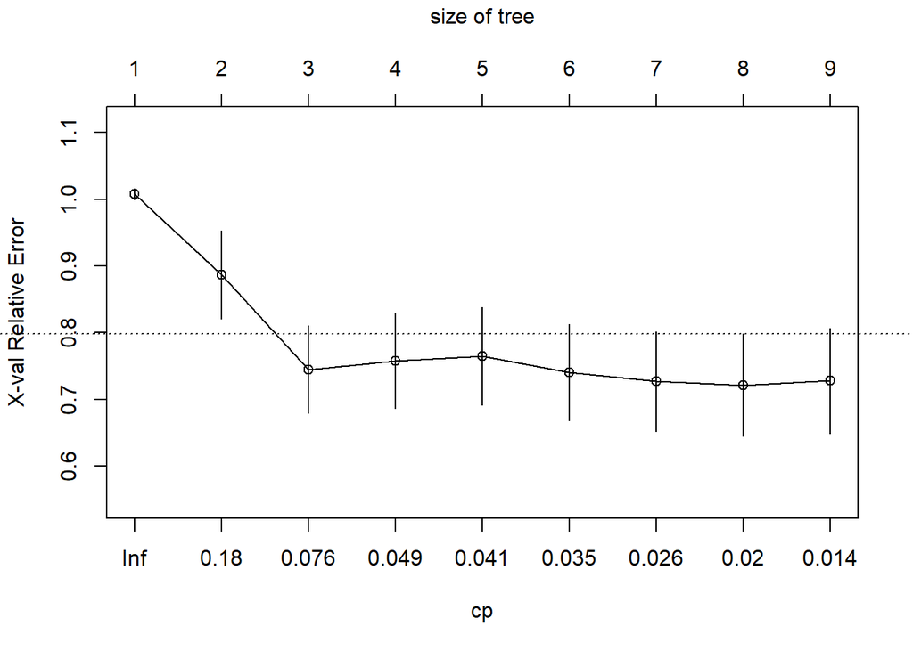

```r
set.seed(999999)
tree_1 <- rpart(target ~., # Set tree formula
data = test_dat) # Set dataset
par(xpd = NA)

plotcp(tree_1)
```

```r
tree_2 <- tree_1 <- rpart(target ~., # Set tree formula
data = test_dat, # Set data
control = rpart.control(cp = 0.026)) # Set parameters


tree_preds <- predict(tree_2, train_dat)
# Join predictions and actual
pred_dat1 <- cbind.data.frame(tree_preds , train_dat$target)
names(pred_dat1) <- c("predictions", "response")
oc1<- optimal.cutpoints(X = "predictions",
                       status = "response",
                       tag.healthy = 0,
                       data = pred_dat1,
                       methods = "MaxEfficiency")

tree_preds_1 <- predict(tree_2, test_dat) # Create predictions for xgboost model

pred_dat1 <- cbind.data.frame(tree_preds_1 , test_dat$target)#
# Convert predictions to classes, using optimal cut-off
tree_pred_class <- rep(0, length(tree_preds_1))
tree_pred_class[tree_preds_1 >= oc1$MaxEfficiency$Global$optimal.cutoff$cutoff[1]] <- 1

t2 <- table(tree_pred_class, test_dat$target) # Create table
confusionMatrix(t2, positive = "1") # Produce confusion matrix
```

```
## Confusion Matrix and Statistics
##
##
## tree_pred_class   0   1
##               0  75   5
##               1  37 121
##
##                Accuracy : 0.8235
##                  95% CI : (0.769, 0.8698)
##     No Information Rate : 0.5294
##     P-Value [Acc > NIR] : < 2.2e-16
##
##                   Kappa : 0.6401
##
##  Mcnemar's Test P-Value : 1.724e-06
##
##             Sensitivity : 0.9603
##             Specificity : 0.6696
##          Pos Pred Value : 0.7658
##          Neg Pred Value : 0.9375
##              Prevalence : 0.5294
##          Detection Rate : 0.5084
##    Detection Prevalence : 0.6639
##       Balanced Accuracy : 0.8150
##
##        'Positive' Class : 1
##
```

#Random Forest

```r
library(randomForest)
library(rpart) # Load rpart for decision trees
library(caret)
set.seed(111111)
bag_mod1 <- randomForest(factor(target) ~., # Set tree formula
                data = train_dat, # Set dataset
                mtry = 11, # Set mtry to number of variables
                ntree = 200) # Set number of trees to use
bag_mod1
```

```
##
## Call:
##  randomForest(formula = factor(target) ~ ., data = train_dat,      mtry = 11, ntree = 200)
##                Type of random forest: classification
##                      Number of trees: 200
## No. of variables tried at each split: 11
##
##         OOB estimate of  error rate: 7.77%
## Confusion matrix:
##     0   1 class.error
## 0 408  41  0.09131403
## 1  33 470  0.06560636
```

```r
bag_preds <- predict(bag_mod1, test_dat)

t3 <- table(bag_preds,test_dat$target) # Create table
confusionMatrix(t3,  positive = "1")
```

```
## Confusion Matrix and Statistics
##
##
## bag_preds   0   1
##         0 102   5
##         1  10 121
##
##                Accuracy : 0.937
##                  95% CI : (0.8982, 0.9643)
##     No Information Rate : 0.5294
##     P-Value [Acc > NIR] : <2e-16
##
##                   Kappa : 0.8732
##
##  Mcnemar's Test P-Value : 0.3017
##
##             Sensitivity : 0.9603
##             Specificity : 0.9107
##          Pos Pred Value : 0.9237
##          Neg Pred Value : 0.9533
##              Prevalence : 0.5294
##          Detection Rate : 0.5084
##    Detection Prevalence : 0.5504
##       Balanced Accuracy : 0.9355
##
##        'Positive' Class : 1
##
```

```r
#pred_dat1 <- cbind.data.frame(bag_preds , test_dat$target)#
# Convert predictions to classes, using optimal cut-off
#bag_pred_class <- rep(0, length(bag_preds))
#bag_pred_class[bag_preds >= oc1$MaxEfficiency$Global$optimal.cutoff$cutoff[1]] <- 1

#t3 <- table(bag_pred_class, test_dat$target) # Create table
#confusionMatrix(t3, positive = "1") # Produce confusion matrix
```

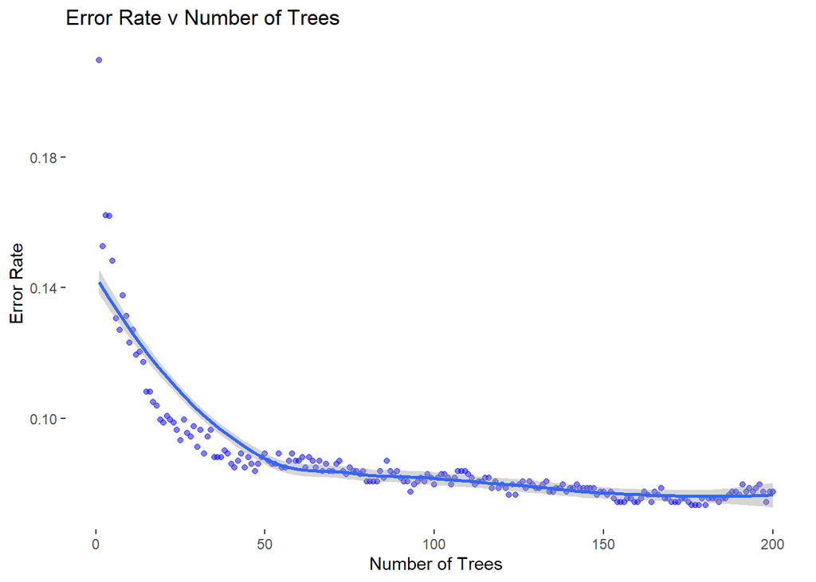

```r
oob_error <- bag_mod1$err.rate[,1] # Extract oob error
plot_dat <- cbind.data.frame(rep(1:length(oob_error)), oob_error) # Create plot data
names(plot_dat) <- c("trees", "oob_error") # Name plot data


# Plot oob error
g_1 <- ggplot(plot_dat, aes(x = trees, y = oob_error)) + # Set x as trees and y as error
  geom_point(alpha = 0.5, color = "blue") + # Select geom point
  geom_smooth() + # Add smoothing line
  theme_bw() + # Set theme
  theme(panel.grid.major = element_blank(), # Remove grid
        panel.grid.minor = element_blank(), # Remove grid
        panel.border = element_blank(), # Remove grid
        panel.background = element_blank()) + # Remove grid
  labs(x = "Number of Trees", title = "Error Rate v Number of Trees",
       y = "Error Rate")  # Set labels
g_1 # Print plot
```

```r
set.seed(111111)
bag_mod2 <- randomForest(factor(target) ~., # Set tree formula
                data = train_dat, # Set dataset
                mtry = 11, # Set mtry to number of variables
                ntree = 1000) # Set number of trees to use
bag_mod2
```

```
##
## Call:
##  randomForest(formula = factor(target) ~ ., data = train_dat,      mtry = 11, ntree = 1000)
##                Type of random forest: classification
##                      Number of trees: 1000
## No. of variables tried at each split: 11
##
##         OOB estimate of  error rate: 8.72%
## Confusion matrix:
##     0   1 class.error
## 0 406  43  0.09576837
## 1  40 463  0.07952286
```

```r
bag_preds1 <- predict(bag_mod2, test_dat)

t4 <- table(bag_preds1,test_dat$target) # Create table
confusionMatrix(t4,  positive = "1")
```

```
## Confusion Matrix and Statistics
##
##
## bag_preds1   0   1
##          0 102   5
##          1  10 121
##
##                Accuracy : 0.937
##                  95% CI : (0.8982, 0.9643)
##     No Information Rate : 0.5294
##     P-Value [Acc > NIR] : <2e-16
##
##                   Kappa : 0.8732
##
##  Mcnemar's Test P-Value : 0.3017
##
##             Sensitivity : 0.9603
##             Specificity : 0.9107
##          Pos Pred Value : 0.9237
##          Neg Pred Value : 0.9533
##              Prevalence : 0.5294
##          Detection Rate : 0.5084
##    Detection Prevalence : 0.5504
##       Balanced Accuracy : 0.9355
##
##        'Positive' Class : 1
##
```

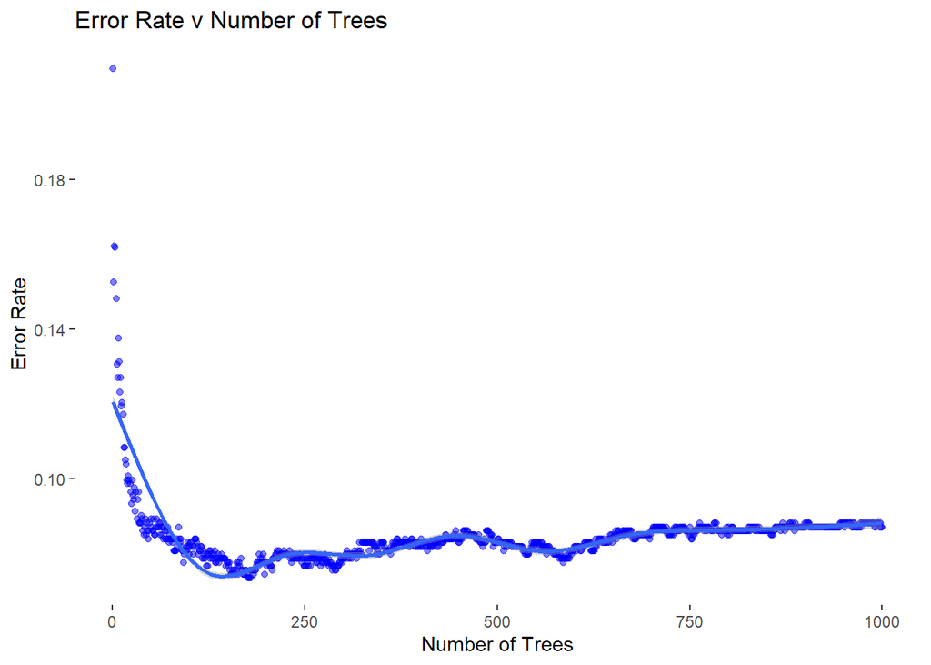

```r
oob_error <- bag_mod2$err.rate[,1] # Extract oob error
plot_dat <- cbind.data.frame(rep(1:length(oob_error)), oob_error) # Create plot data
names(plot_dat) <- c("trees", "oob_error") # Name plot data


# Plot oob error
g_2 <- ggplot(plot_dat, aes(x = trees, y = oob_error)) + # Set x as trees and y as error
  geom_point(alpha = 0.5, color = "blue") + # Select geom point
  geom_smooth() + # Add smoothing line
  theme_bw() + # Set theme
  theme(panel.grid.major = element_blank(), # Remove grid
        panel.grid.minor = element_blank(), # Remove grid
        panel.border = element_blank(), # Remove grid
        panel.background = element_blank()) + # Remove grid
  labs(x = "Number of Trees", title = "Error Rate v Number of Trees",
       y = "Error Rate")  # Set labels
g_2
```

` Node Size Tuning

```r
set.seed(111111)
trees <- c(10, 25, 50, 100, 200, 500, 1000) # Create vector of possible tree sizes
nodesize <- c(1, 10, 25, 50, 100, 200, 500, 1000) # Create vector of possible node sizes

params <- expand.grid(trees, nodesize) # Expand grid to get data frame of parameter combinations
names(params) <- c("trees", "nodesize") # Name parameter data frame
res_vec <- rep(NA, nrow(params)) # Create vector to store accuracy results

for(i in 1:nrow(params)){ # For each set of parameters
  set.seed(987654) # Set seed for reproducability
  mod <- randomForest(factor(target) ~. , # Set formula
                      data=train_dat,# Set data
                      mtry = 11, # Set number of variables
                      importance = FALSE,  #
                      ntree = params$trees[i], # Set number of trees
                      nodesize = params$nodesize[i]) # Set node size
  res_vec[i] <- 1 - mod$err.rate[nrow(mod$err.rate),1] # Calculate out of bag accuracy
}
```

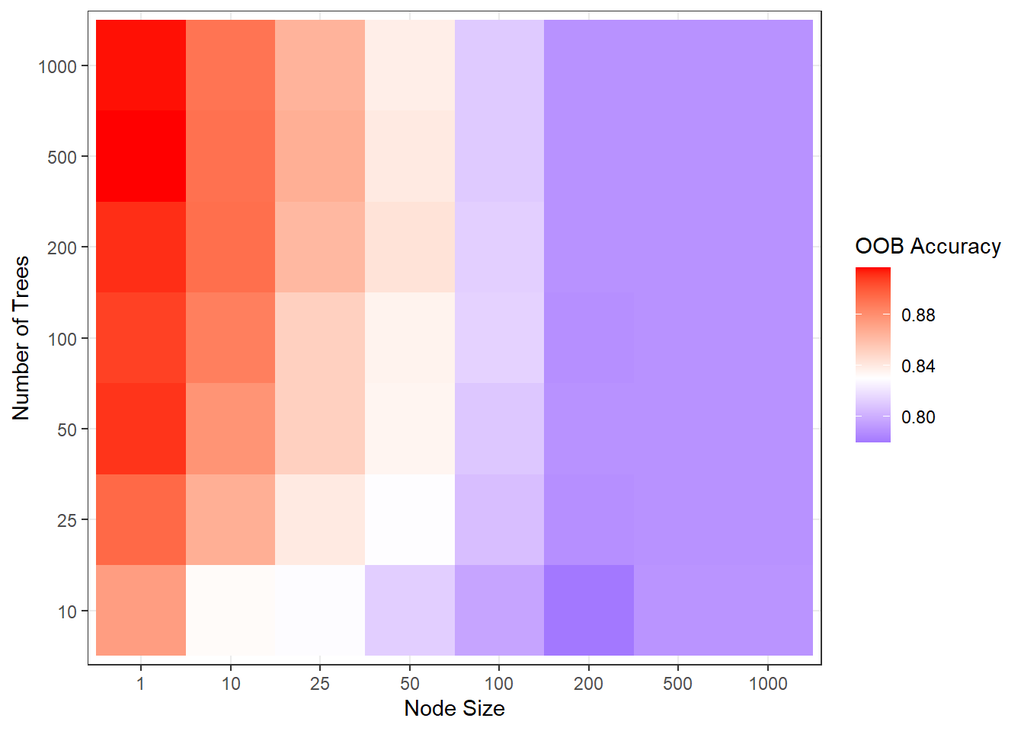

```r
res_db <- cbind.data.frame(params, res_vec) # Join parameters and accuracy results
names(res_db)[3] <- "oob_error" # Name accuracy results column

res_db$trees <- as.factor(res_db$trees) # Convert tree number to factor for plotting
res_db$nodesize <- as.factor(res_db$nodesize) # Convert node size to factor for plotting
g_2 <- ggplot(res_db, aes(y = trees, x = nodesize, fill = oob_error)) + # set aesthetics
  geom_tile() + # Use geom_tile for heatmap
  theme_bw() + # Set theme
  scale_fill_gradient2(low = "blue", # Choose low color
    mid = "white", # Choose mid color
    high = "red", # Choose high color
    midpoint =mean(res_db$oob_error), # Choose mid point
    space = "Lab",
    na.value ="grey", # Choose NA value
    guide = "colourbar", # Set color bar
    aesthetics = "fill") + # Select aesthetics to apply
  labs(x = "Node Size", y = "Number of Trees", fill = "OOB Accuracy") # Set labels
g_2
```

Low node size and high number of trees(500-1000) as well as 50 perform better. Let us try with optimal parameters of node size=1 and tree size 350 as well as node size=1, tree size 50

```r
set.seed(111111)
bag_mod_3 <- randomForest(factor(target) ~., # Set tree formula
                data = train_dat, # Set dataset
                mtry = 11, # Set number of variables
                ntree = 350, # Set number of trees
                nodesize = 1,importance = TRUE,
                proximity = TRUE) # Set node size

bag_preds_3 <- predict(bag_mod_3, test_dat) # Create predictions for test data


t5 <- table(bag_preds_3,  test_dat$target) # Create table
confusionMatrix(t5,  positive = "1")
```

```
## Confusion Matrix and Statistics
##
##
## bag_preds_3   0   1
##           0 102   5
##           1  10 121
##
##                Accuracy : 0.937
##                  95% CI : (0.8982, 0.9643)
##     No Information Rate : 0.5294
##     P-Value [Acc > NIR] : <2e-16
##
##                   Kappa : 0.8732
##
##  Mcnemar's Test P-Value : 0.3017
##
##             Sensitivity : 0.9603
##             Specificity : 0.9107
##          Pos Pred Value : 0.9237
##          Neg Pred Value : 0.9533
##              Prevalence : 0.5294
##          Detection Rate : 0.5084
##    Detection Prevalence : 0.5504
##       Balanced Accuracy : 0.9355
##
##        'Positive' Class : 1
##
```

```r
set.seed(111111)
bag_mod_4 <- randomForest(factor(target) ~., # Set tree formula
                data = train_dat, # Set dataset
                mtry = 11, # Set number of variables
                ntree = 50, # Set number of trees
                nodesize = 1,importance = TRUE,
                proximity = TRUE) # Set node size

bag_preds_4 <- predict(bag_mod_3, test_dat) # Create predictions for test data


t6 <- table(bag_preds_4,  test_dat$target) # Create table
confusionMatrix(t6,  positive = "1")
```

```
## Confusion Matrix and Statistics
##
##
## bag_preds_4   0   1
##           0 102   5
##           1  10 121
##
##                Accuracy : 0.937
##                  95% CI : (0.8982, 0.9643)
##     No Information Rate : 0.5294
##     P-Value [Acc > NIR] : <2e-16
##
##                   Kappa : 0.8732
##
##  Mcnemar's Test P-Value : 0.3017
##
##             Sensitivity : 0.9603
##             Specificity : 0.9107
##          Pos Pred Value : 0.9237
##          Neg Pred Value : 0.9533
##              Prevalence : 0.5294
##          Detection Rate : 0.5084
##    Detection Prevalence : 0.5504
##       Balanced Accuracy : 0.9355
##
##        'Positive' Class : 1
##
```

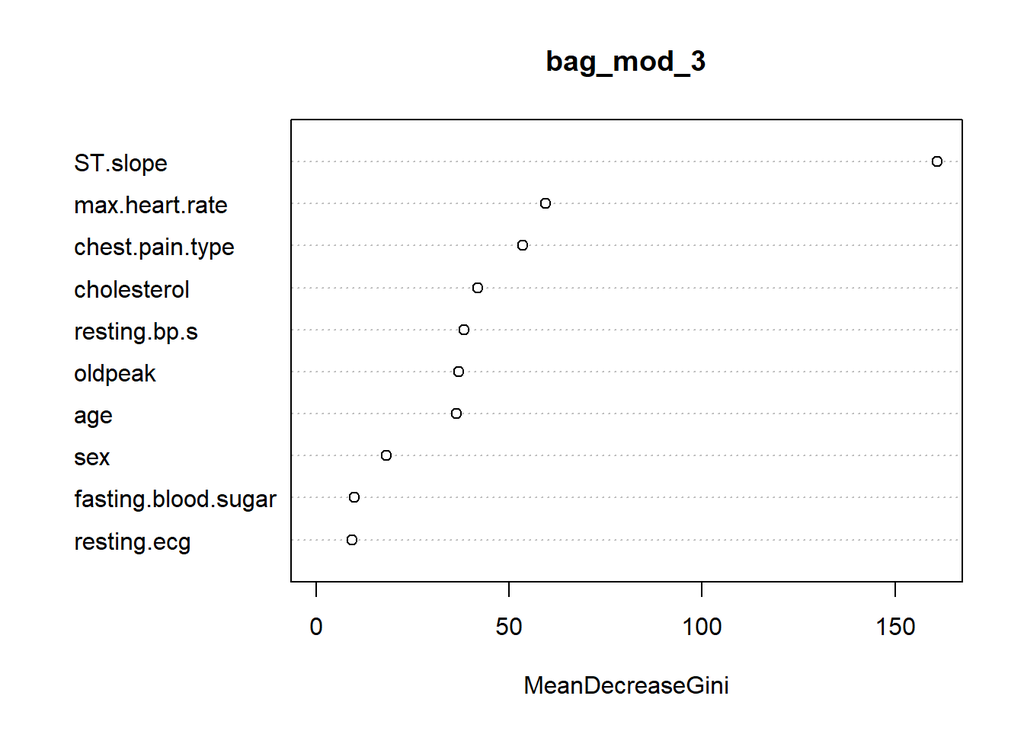

```r
varImpPlot(bag_mod_3, type =2, n.var = 10)
```

ST.Slope is by far the most important factor. Max heart rate and chest pain type are also important

#XGBoost

```r
 # Load XGBoost
#install.packages("caret")


#install.packages("caret")
#install.packages("OptimalCutpoints")
#install.packages("ggplot2")
#library(devtools)

#install_github("AppliedDataSciencePartners/xgboostExplainer")

#install.packages("devtools")
#library(devtools)
#install_github("AppliedDataSciencePartners/xgboostExplainer")

library(xgboostExplainer) # Load XGboost Explainer
library(pROC)
library(xgboost)
library(SHAPforxgboost)
#library(caret)
names(train_dat)
```

```
##  [1] "age"                 "sex"                 "chest.pain.type"
##  [4] "resting.bp.s"        "cholesterol"         "fasting.blood.sugar"
##  [7] "resting.ecg"         "max.heart.rate"      "exercise.angina"
## [10] "oldpeak"             "ST.slope"            "target"
```

```r
# Create training matrix
dtrain <- xgb.DMatrix(data = as.matrix(train_dat[, 1:11]), label = as.numeric(train_dat$target))
# Create test matrix
dtest <- xgb.DMatrix(data = as.matrix(test_dat[, 1:11]), label = as.numeric(test_dat$target) )
```

Comparison

```r
set.seed(111111)
bst_1 <- xgboost(data = dtrain, # Set training data

               nrounds = 100, # Set number of rounds

               verbose = 1, # 1 - Prints out fit
                print_every_n = 20,

               objective = "binary:logistic", # Set objective
               eval_metric = "auc",
               eval_metric = "error")
boost_preds <- predict(bst_1, dtrain) # Create predictions for xgboost model
# Join predictions and actual
pred_dat <- cbind.data.frame(boost_preds , train_dat$target)
names(pred_dat) <- c("predictions", "response")
oc<- optimal.cutpoints(X = "predictions",
                       status = "response",
                       tag.healthy = 0,
                       data = pred_dat,
                       methods = "MaxEfficiency")

boost_preds_1 <- predict(bst_1, dtest) # Create predictions for xgboost model

pred_dat <- cbind.data.frame(boost_preds_1 , test_dat$target)#
# Convert predictions to classes, using optimal cut-off
boost_pred_class <- rep(0, length(boost_preds_1))
boost_pred_class[boost_preds_1 >= oc$MaxEfficiency$Global$optimal.cutoff$cutoff[1]] <- 1


t7 <- table(boost_pred_class, test_dat$target) # Create table
confusionMatrix(t7, positive = "1") # Produce confusion matrix
```

```
## Confusion Matrix and Statistics
##
##
## boost_pred_class   0   1
##                0 104  11
##                1   8 115
##
##                Accuracy : 0.9202
##                  95% CI : (0.8781, 0.9513)
##     No Information Rate : 0.5294
##     P-Value [Acc > NIR] : <2e-16
##
##                   Kappa : 0.84
##
##  Mcnemar's Test P-Value : 0.6464
##
##             Sensitivity : 0.9127
##             Specificity : 0.9286
##          Pos Pred Value : 0.9350
##          Neg Pred Value : 0.9043
##              Prevalence : 0.5294
##          Detection Rate : 0.4832
##    Detection Prevalence : 0.5168
##       Balanced Accuracy : 0.9206
##
##        'Positive' Class : 1
##
```

XGBoost Tuning

```r
set.seed(111111)
bst <- xgb.cv(data = dtrain, # Set training data

              nfold = 5, # Use 5 fold cross-validation

               eta = 0.1, # Set learning rate

               nrounds = 1000, # Set number of rounds
               early_stopping_rounds = 50, # Set number of rounds to stop at if there is no improvement

               verbose = 1, # 1 - Prints out fit
               nthread = 1, # Set number of parallel threads
               print_every_n = 20, # Prints out result every 20th iteration

               objective = "binary:logistic", # Set objective
               eval_metric = "auc",
               eval_metric = "error")
```

```
## Multiple eval metrics are present. Will use test_error for early stopping.
## Will train until test_error hasn't improved in 50 rounds.
##
## Stopping. Best iteration:
```

101 optimal iterations for our model. Setting the number of iterations to 500 and including an early stop parameter of 90 for our next round of tuning. Next we will tune max.depth and min_child_weight.

```r
max_depth_vals <- c(3, 5, 7, 10, 15) # Create vector of max depth values
min_child_weight <- c(1,3,5,7, 10, 15) # Create vector of min child values

# Expand grid of parameter values
cv_params <- expand.grid(max_depth_vals, min_child_weight)
names(cv_params) <- c("max_depth", "min_child_weight")
# Create results vector
auc_vec <- error_vec <- rep(NA, nrow(cv_params))
# Loop through results
for(i in 1:nrow(cv_params)){
  set.seed(111111)
  bst_tune <- xgb.cv(data = dtrain, # Set training data

              nfold = 5, # Use 5 fold cross-validation

              eta = 0.1, # Set learning rate
              max.depth = cv_params$max_depth[i], # Set max depth
              min_child_weight = cv_params$min_child_weight[i], # Set minimum number of samples in node to split


              nrounds = 500, # Set number of rounds
              early_stopping_rounds = 90, # Set number of rounds to stop at if there is no improvement

              verbose = 1, # 1 - Prints out fit
              nthread = 1, # Set number of parallel threads
              print_every_n = 20, # Prints out result every 20th iteration

              objective = "binary:logistic", # Set objective
              eval_metric = "auc", # Set evaluation metric to use
              eval_metric = "error") # Set evaluation metric to use
  auc_vec[i] <- bst_tune$evaluation_log$test_auc_mean[bst_tune$best_ntreelimit]
  error_vec[i] <- bst_tune$evaluation_log$test_error_mean[bst_tune$best_ntreelimit]

}
```

[output not shown]

[output cut: 88 more lines]

[output not shown]

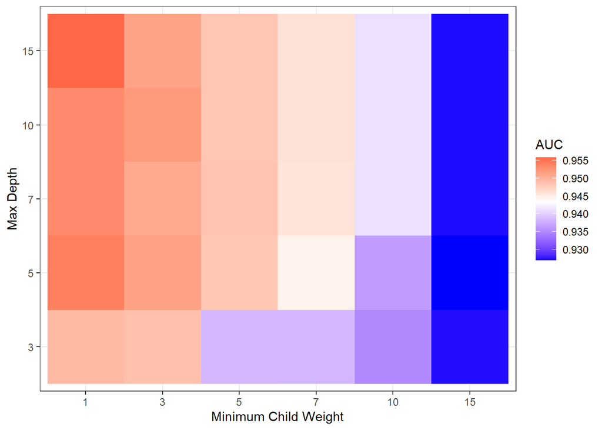

```r
res_db <- cbind.data.frame(cv_params, auc_vec, error_vec)
names(res_db)[3:4] <- c("auc", "error")
res_db$max_depth <- as.factor(res_db$max_depth) # Convert tree number to factor for plotting
res_db$min_child_weight <- as.factor(res_db$min_child_weight) # Convert node size to factor for plotting
# Print AUC heatmap
g_3 <- ggplot(res_db, aes(y = max_depth, x = min_child_weight, fill = auc)) + # set aesthetics
  geom_tile() + # Use geom_tile for heatmap
  theme_bw() + # Set theme
  scale_fill_gradient2(low = "blue", # Choose low color
    mid = "white", # Choose mid color
    high = "red", # Choose high color
    midpoint =mean(res_db$auc), # Choose mid point
    space = "Lab",
    na.value ="grey", # Choose NA value
    guide = "colourbar", # Set color bar
    aesthetics = "fill") + # Select aesthetics to apply
  labs(x = "Minimum Child Weight", y = "Max Depth", fill = "AUC") # Set labels
g_3
```

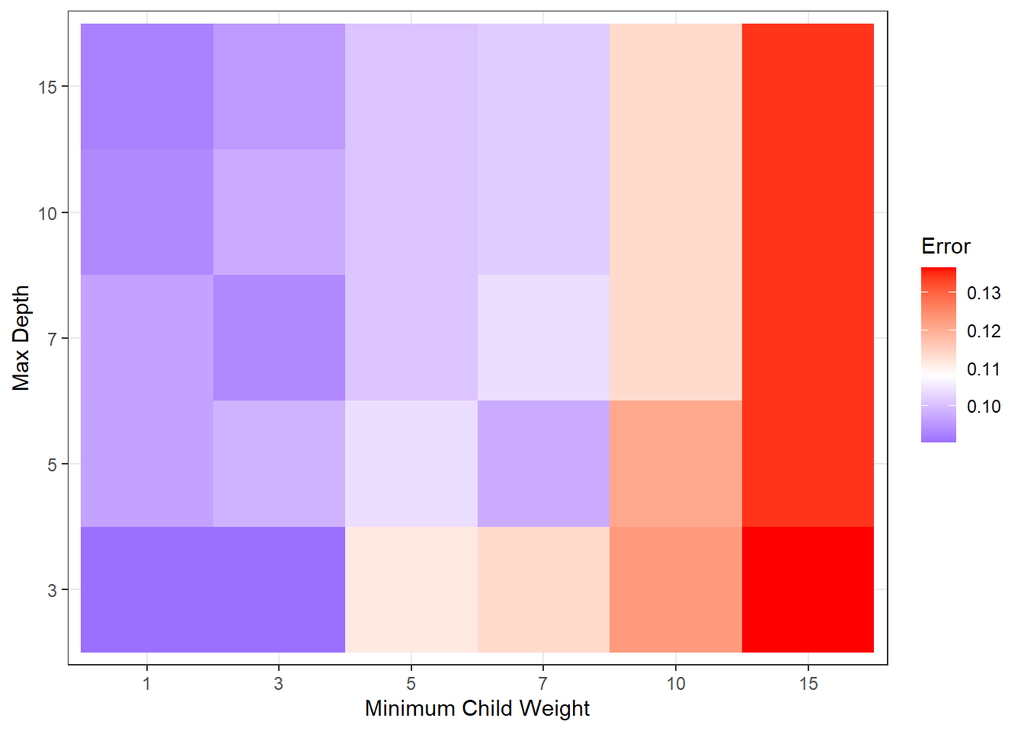

```r
g_4 <- ggplot(res_db, aes(y = max_depth, x = min_child_weight, fill = error)) + # set aesthetics
  geom_tile() + # Use geom_tile for heatmap
  theme_bw() + # Set theme
  scale_fill_gradient2(low = "blue", # Choose low color
    mid = "white", # Choose mid color
    high = "red", # Choose high color
    midpoint =mean(res_db$error), # Choose mid point
    space = "Lab",
    na.value ="grey", # Choose NA value
    guide = "colourbar", # Set color bar
    aesthetics = "fill") + # Select aesthetics to apply
  labs(x = "Minimum Child Weight", y = "Max Depth", fill = "Error") # Set labels
g_4
```

```r
res_db
```

```
##    max_depth min_child_weight       auc     error
## 1          3                1 0.9493792 0.0903896
## 2          5                1 0.9540748 0.0966778
## 3          7                1 0.9532680 0.0966890
## 4         10                1 0.9531900 0.0935032
## 5         15                1 0.9558378 0.0924784
## 6          3                3 0.9488076 0.0904062
## 7          5                3 0.9514762 0.0987830
## 8          7                3 0.9507146 0.0935308
## 9         10                3 0.9519846 0.0977194
## 10        15                3 0.9513130 0.0956360
## 11         3                5 0.9383846 0.1114094
## 12         5                5 0.9482448 0.1040518
## 13         7                5 0.9486456 0.1008608
## 14        10                5 0.9483558 0.1008830
```

[output cut: 16 more lines]

Tuning gamma

```r
gamma_vals <- c(0, 0.05, 0.1, 0.15, 0.2) # Create vector of gamma values

# Be Careful - This can take a very long time to run
set.seed(111111)
auc_vec <- error_vec <- rep(NA, length(gamma_vals))
for(i in 1:length(gamma_vals)){
  bst_tune <- xgb.cv(data = dtrain, # Set training data

              nfold = 5, # Use 5 fold cross-validation

              eta = 0.1, # Set learning rate
              max.depth = 5, # Set max depth
              min_child_weight = 1, # Set minimum number of samples in node to split
              gamma = gamma_vals[i], # Set minimum loss reduction for split



              nrounds = 500, # Set number of rounds
              early_stopping_rounds = 90, # Set number of rounds to stop at if there is no improvement

              verbose = 1, # 1 - Prints out fit
              nthread = 1, # Set number of parallel threads
              print_every_n = 20, # Prints out result every 20th iteration

              objective = "binary:logistic", # Set objective
              eval_metric = "auc", # Set evaluation metric to use
              eval_metric = "error") # Set evaluation metric to use
  auc_vec[i] <- bst_tune$evaluation_log$test_auc_mean[bst_tune$best_ntreelimit]
  error_vec[i] <- bst_tune$evaluation_log$test_error_mean[bst_tune$best_ntreelimit]

}
```

```
## Multiple eval metrics are present. Will use test_error for early stopping.
## Will train until test_error hasn't improved in 90 rounds.
##
## Stopping. Best iteration:
##
## Multiple eval metrics are present. Will use test_error for early stopping.
## Will train until test_error hasn't improved in 90 rounds.
##
## Stopping. Best iteration:
##
## Multiple eval metrics are present. Will use test_error for early stopping.
## Will train until test_error hasn't improved in 90 rounds.
##
## Stopping. Best iteration:
##
## Multiple eval metrics are present. Will use test_error for early stopping.
## Will train until test_error hasn't improved in 90 rounds.
##
## Stopping. Best iteration:
##
## Multiple eval metrics are present. Will use test_error for early stopping.
## Will train until test_error hasn't improved in 90 rounds.
##
## Stopping. Best iteration:
```

```r
cbind.data.frame(gamma_vals, auc_vec, error_vec)
```

```
##   gamma_vals   auc_vec error_vec
## 1       0.00 0.9540748 0.0966778
## 2       0.05 0.9478618 0.0913760
## 3       0.10 0.9472066 0.0987280
## 4       0.15 0.9540458 0.0840398
## 5       0.20 0.9506398 0.1008442
```

```r
set.seed(111111)
bst <- xgb.cv(data = dtrain, # Set training data

              nfold = 5, # Use 5 fold cross-validation

              eta = 0.1, # Set learning rate
              max.depth = 5, # Set max depth
              min_child_weight = 1, # Set minimum number of samples in node to split
              gamma = .15, # Set minimum loss reduction for split


              nrounds = 1000, # Set number of rounds
              early_stopping_rounds = 50, # Set number of rounds to stop at if there is no improvement

              verbose = 1, # 1 - Prints out fit
              nthread = 1, # Set number of parallel threads
              print_every_n = 20, # Prints out result every 20th iteration

              objective = "binary:logistic", # Set objective
              eval_metric = "auc",
              eval_metric = "error")
```

```
## Multiple eval metrics are present. Will use test_error for early stopping.
## Will train until test_error hasn't improved in 50 rounds.
##
## Stopping. Best iteration:
```

Optimal number of trees with current set of parameters is ~100

Tuning the subsample and colsample_by_tree parameters

```r
# Be Careful - This can take a very long time to run
subsample <- c(0.6, 0.7, 0.8, 0.9, 1) # Create vector of subsample values
colsample_by_tree <- c(0.6, 0.7, 0.8, 0.9, 1) # Create vector of col sample values

# Expand grid of tuning parameters
cv_params <- expand.grid(subsample, colsample_by_tree)
names(cv_params) <- c("subsample", "colsample_by_tree")
# Create vectors to store results
auc_vec <- error_vec <- rep(NA, nrow(cv_params))
# Loop through parameter values
for(i in 1:nrow(cv_params)){
  set.seed(111111)
  bst_tune <- xgb.cv(data = dtrain, # Set training data

              nfold = 5, # Use 5 fold cross-validation

              eta = 0.1, # Set learning rate
              max.depth = 5, # Set max depth
              min_child_weight = 1, # Set minimum number of samples in node to split
              gamma = .15, # Set minimum loss reduction for split
              subsample = cv_params$subsample[i], # Set proportion of training data to use in tree
              colsample_bytree = cv_params$colsample_by_tree[i], # Set number of variables to use in each tree

              nrounds = 500, # Set number of rounds
              early_stopping_rounds = 100, # Set number of rounds to stop at if there is no improvement

              verbose = 1, # 1 - Prints out fit
              nthread = 1, # Set number of parallel threads
              print_every_n = 20, # Prints out result every 20th iteration

              objective = "binary:logistic", # Set objective
              eval_metric = "auc", # Set evaluation metric to use
              eval_metric = "error") # Set evaluation metric to use
  auc_vec[i] <- bst_tune$evaluation_log$test_auc_mean[bst_tune$best_ntreelimit]
  error_vec[i] <- bst_tune$evaluation_log$test_error_mean[bst_tune$best_ntreelimit]

}
```

[output not shown]

[output cut: 67 more lines]

[output not shown]

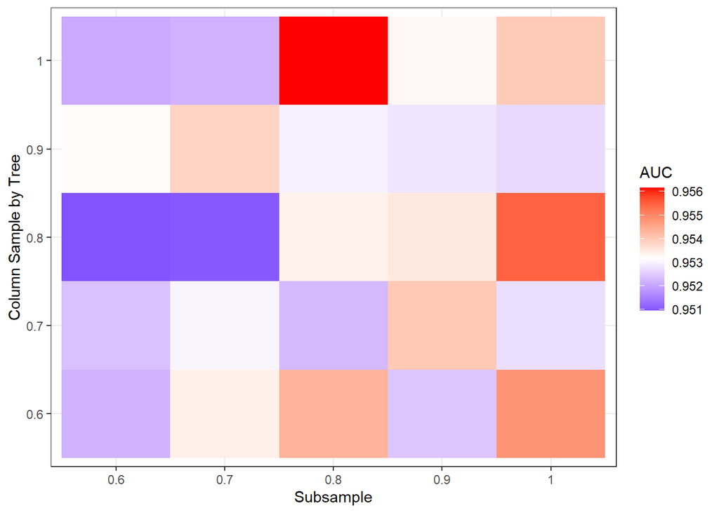

```r
res_db <- cbind.data.frame(cv_params, auc_vec, error_vec)
names(res_db)[3:4] <- c("auc", "error")
res_db$subsample <- as.factor(res_db$subsample) # Convert tree number to factor for plotting
res_db$colsample_by_tree <- as.factor(res_db$colsample_by_tree) # Convert node size to factor for plotting
g_5 <- ggplot(res_db, aes(y = colsample_by_tree, x = subsample, fill = auc)) + # set aesthetics
  geom_tile() + # Use geom_tile for heatmap
  theme_bw() + # Set theme
  scale_fill_gradient2(low = "blue", # Choose low color
    mid = "white", # Choose mid color
    high = "red", # Choose high color
    midpoint =mean(res_db$auc), # Choose mid point
    space = "Lab",
    na.value ="grey", # Choose NA value
    guide = "colourbar", # Set color bar
    aesthetics = "fill") + # Select aesthetics to apply
  labs(x = "Subsample", y = "Column Sample by Tree", fill = "AUC") # Set labels
g_5
```

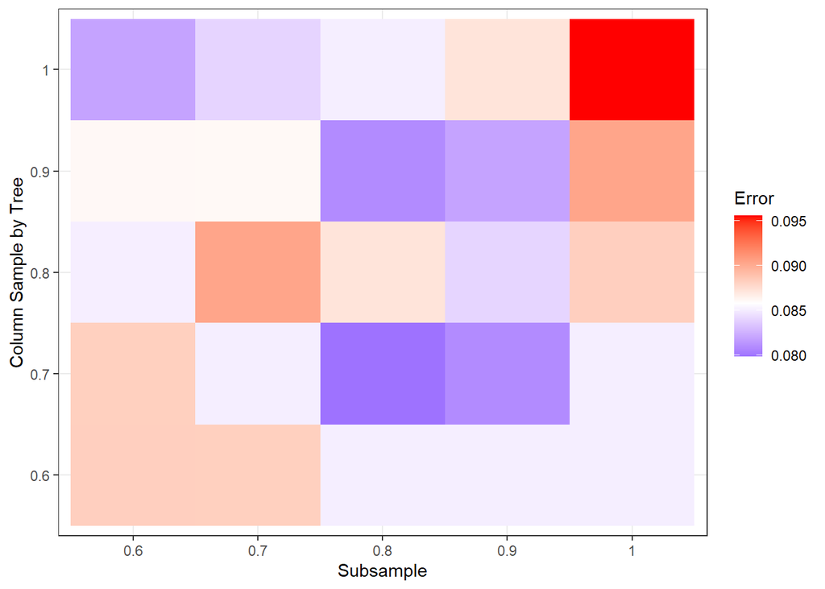

```r
g_6 <- ggplot(res_db, aes(y = colsample_by_tree, x = subsample, fill = error)) + # set aesthetics
  geom_tile() + # Use geom_tile for heatmap
  theme_bw() + # Set theme
  scale_fill_gradient2(low = "blue", # Choose low color
    mid = "white", # Choose mid color
    high = "red", # Choose high color
    midpoint =mean(res_db$error), # Choose mid point
    space = "Lab",
    na.value ="grey", # Choose NA value
    guide = "colourbar", # Set color bar
    aesthetics = "fill") + # Select aesthetics to apply
  labs(x = "Subsample", y = "Column Sample by Tree", fill = "Error") # Set labels
g_6
```

```r
res_db
```

```
##    subsample colsample_by_tree       auc     error
## 1        0.6               0.6 0.9521846 0.0882842
## 2        0.7               0.6 0.9534144 0.0882620
## 3        0.8               0.6 0.9543480 0.0851318
## 4        0.9               0.6 0.9524252 0.0851262
## 5          1               0.6 0.9548162 0.0851374
## 6        0.6               0.7 0.9523608 0.0882676
## 7        0.7               0.7 0.9530410 0.0851432
## 8        0.8               0.7 0.9522778 0.0798852
## 9        0.9               0.7 0.9540236 0.0809378
## 10         1               0.7 0.9527490 0.0851374
## 11       0.6               0.8 0.9509592 0.0851540
## 12       0.7               0.8 0.9510270 0.0903950
## 13       0.8               0.8 0.9533802 0.0872206
## 14       0.9               0.8 0.9535292 0.0840792
## 15         1               0.8 0.9554864 0.0882786
## 16       0.6               0.9 0.9532354 0.0861846
## 17       0.7               0.9 0.9538572 0.0861624
## 18       0.8               0.9 0.9529922 0.0809324
## 19       0.9               0.9 0.9528320 0.0819796
## 20         1               0.9 0.9526860 0.0903730
## 21       0.6                 1 0.9520846 0.0819848
## 22       0.7                 1 0.9521692 0.0840626
## 23       0.8                 1 0.9561640 0.0851428
## 24       0.9                 1 0.9532924 0.0872370
## 25         1                 1 0.9539834 0.0956196
```

Finally we will tune eta

```r
set.seed(111111)
bst_mod_1 <- xgb.cv(data = dtrain, # Set training data

              nfold = 5, # Use 5 fold cross-validation

              eta = 0.3, # Set learning rate
              max.depth = 5, # Set max depth
              min_child_weight = 1, # Set minimum number of samples in node to split
              gamma = .15,
              subsample = 0.8, # Set proportion of training data to use in tree
              colsample_bytree =  0.9, # Set number of variables to use in each tree

              nrounds = 500, # Set number of rounds
              early_stopping_rounds = 100, # Set number of rounds to stop at if there is no improvement

              verbose = 1, # 1 - Prints out fit
              nthread = 1, # Set number of parallel threads
              print_every_n = 20, # Prints out result every 20th iteration

              objective = "binary:logistic", # Set objective
              eval_metric = "auc",
              eval_metric = "error")
```

```
## Multiple eval metrics are present. Will use test_error for early stopping.
## Will train until test_error hasn't improved in 100 rounds.
##
## Stopping. Best iteration:
```

```r
set.seed(111111)
bst_mod_2 <- xgb.cv(data = dtrain, # Set training data

              nfold = 5, # Use 5 fold cross-validation

              eta = 0.1, # Set learning rate
              max.depth = 5, # Set max depth
              min_child_weight = 1, # Set minimum number of samples in node to split
              gamma = .15,
              subsample = 0.8, # Set proportion of training data to use in tree
              colsample_bytree =  0.9, # Set number of variables to use in each tree

              nrounds = 500, # Set number of rounds
              early_stopping_rounds = 100, # Set number of rounds to stop at if there is no improvement

              verbose = 1, # 1 - Prints out fit
              nthread = 1, # Set number of parallel threads
              print_every_n = 20, # Prints out result every 20th iteration

              objective = "binary:logistic", # Set objective
              eval_metric = "auc",
              eval_metric = "error")
```

```
## Multiple eval metrics are present. Will use test_error for early stopping.
## Will train until test_error hasn't improved in 100 rounds.
##
## Stopping. Best iteration:
```

```r
set.seed(111111)
bst_mod_3 <- xgb.cv(data = dtrain, # Set training data

              nfold = 5, # Use 5 fold cross-validation

              eta = 0.05, # Set learning rate
              max.depth = 5, # Set max depth
              min_child_weight = 1, # Set minimum number of samples in node to split
              gamma = .15,
              subsample = 0.8, # Set proportion of training data to use in tree
              colsample_bytree =  0.9, # Set number of variables to use in each tree

              nrounds = 500, # Set number of rounds
              early_stopping_rounds = 100, # Set number of rounds to stop at if there is no improvement

              verbose = 1, # 1 - Prints out fit
              nthread = 1, # Set number of parallel threads
              print_every_n = 20, # Prints out result every 20th iteration

              objective = "binary:logistic", # Set objective
              eval_metric = "auc",
              eval_metric = "error")
```

```
## Multiple eval metrics are present. Will use test_error for early stopping.
## Will train until test_error hasn't improved in 100 rounds.
##
## Stopping. Best iteration:
```

```r
set.seed(111111)
bst_mod_4 <- xgb.cv(data = dtrain, # Set training data

              nfold = 5, # Use 5 fold cross-validation

              eta = 0.01, # Set learning rate
              max.depth = 5, # Set max depth
              min_child_weight = 1, # Set minimum number of samples in node to split
              gamma = .15,
              subsample = 0.8, # Set proportion of training data to use in tree
              colsample_bytree =  0.9, # Set number of variables to use in each tree

              nrounds = 500, # Set number of rounds
              early_stopping_rounds = 100, # Set number of rounds to stop at if there is no improvement

              verbose = 1, # 1 - Prints out fit
              nthread = 1, # Set number of parallel threads
              print_every_n = 20, # Prints out result every 20th iteration

              objective = "binary:logistic", # Set objective
              eval_metric = "auc",
              eval_metric = "error")
```

```
## Multiple eval metrics are present. Will use test_error for early stopping.
## Will train until test_error hasn't improved in 100 rounds.
##
```

```r
set.seed(111111)
bst_mod_5 <- xgb.cv(data = dtrain, # Set training data

              nfold = 5, # Use 5 fold cross-validation

              eta = 0.005, # Set learning rate
              max.depth = 5, # Set max depth
              min_child_weight = 1, # Set minimum number of samples in node to split
              gamma = .15,
              subsample = 0.8, # Set proportion of training data to use in tree
              colsample_bytree =  0.9, # Set number of variables to use in each tree

              nrounds = 500, # Set number of rounds
              early_stopping_rounds = 100, # Set number of rounds to stop at if there is no improvement

              verbose = 1, # 1 - Prints out fit
              nthread = 1, # Set number of parallel threads
              print_every_n = 20, # Prints out result every 20th iteration

              objective = "binary:logistic", # Set objective
              eval_metric = "auc",
              eval_metric = "error")
```

```
## Multiple eval metrics are present. Will use test_error for early stopping.
## Will train until test_error hasn't improved in 100 rounds.
##
```

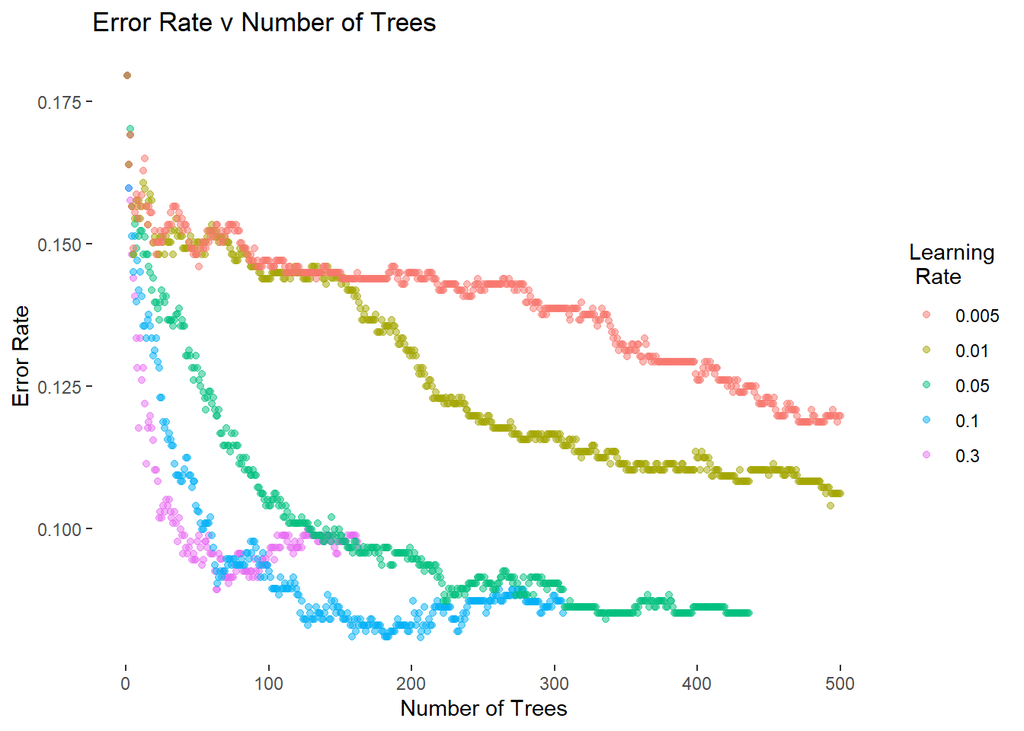

```r
# Extract results for model with eta = 0.3
pd1 <- cbind.data.frame(bst_mod_1$evaluation_log[,c("iter", "test_error_mean")], rep(0.3, nrow(bst_mod_1$evaluation_log)))
names(pd1)[3] <- "eta"
# Extract results for model with eta = 0.1
pd2 <- cbind.data.frame(bst_mod_2$evaluation_log[,c("iter", "test_error_mean")], rep(0.1, nrow(bst_mod_2$evaluation_log)))
names(pd2)[3] <- "eta"
# Extract results for model with eta = 0.05
pd3 <- cbind.data.frame(bst_mod_3$evaluation_log[,c("iter", "test_error_mean")], rep(0.05, nrow(bst_mod_3$evaluation_log)))
names(pd3)[3] <- "eta"
# Extract results for model with eta = 0.01
pd4 <- cbind.data.frame(bst_mod_4$evaluation_log[,c("iter", "test_error_mean")], rep(0.01, nrow(bst_mod_4$evaluation_log)))
names(pd4)[3] <- "eta"
# Extract results for model with eta = 0.005
pd5 <- cbind.data.frame(bst_mod_5$evaluation_log[,c("iter", "test_error_mean")], rep(0.005, nrow(bst_mod_5$evaluation_log)))
names(pd5)[3] <- "eta"
# Join datasets
plot_data <- rbind.data.frame(pd1, pd2, pd3, pd4, pd5)
# Converty ETA to factor
plot_data$eta <- as.factor(plot_data$eta)
# Plot points
g_7 <- ggplot(plot_data, aes(x = iter, y = test_error_mean, color = eta))+
  geom_point(alpha = 0.5) +
  theme_bw() + # Set theme
  theme(panel.grid.major = element_blank(), # Remove grid
        panel.grid.minor = element_blank(), # Remove grid
        panel.border = element_blank(), # Remove grid
        panel.background = element_blank()) + # Remove grid
  labs(x = "Number of Trees", title = "Error Rate v Number of Trees",
       y = "Error Rate", color = "Learning \n Rate")  # Set labels
g_7
```

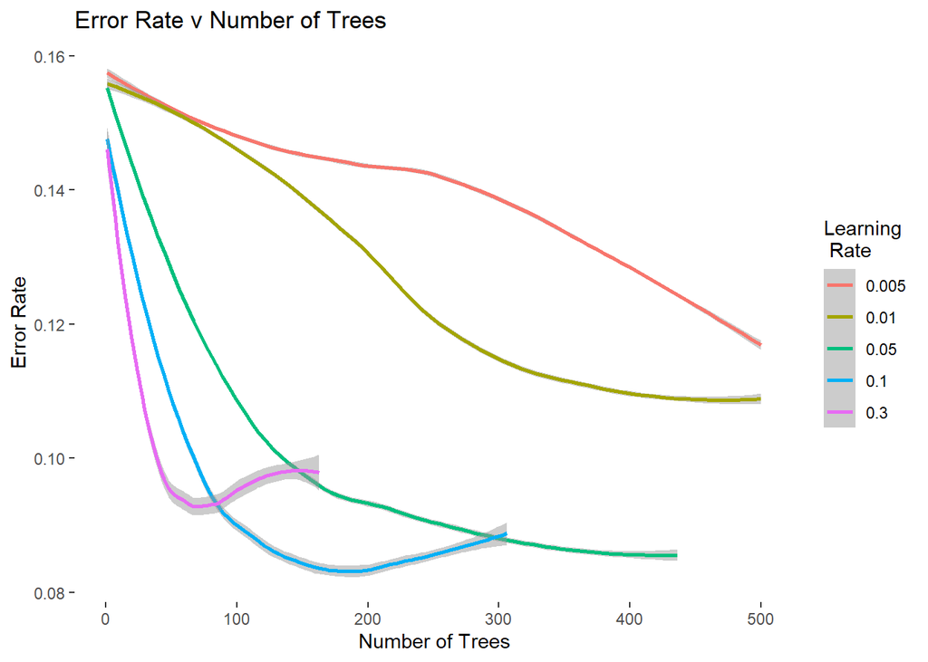

```r
g_8 <- ggplot(plot_data, aes(x = iter, y = test_error_mean, color = eta))+
  geom_smooth(alpha = 0.5) +
  theme_bw() + # Set theme
  theme(panel.grid.major = element_blank(), # Remove grid
        panel.grid.minor = element_blank(), # Remove grid
        panel.border = element_blank(), # Remove grid
        panel.background = element_blank()) + # Remove grid
  labs(x = "Number of Trees", title = "Error Rate v Number of Trees",
       y = "Error Rate", color = "Learning \n Rate")  # Set labels
g_8
```

Final Model using tuned parameters

```r
set.seed(111111)
bst_final <- xgboost(data = dtrain, # Set training data



              eta = 0.05, # Set learning rate
              max.depth =  5, # Set max depth
              min_child_weight = 1, # Set minimum number of samples in node to split
              gamma = .15, # Set minimum loss reduction for split
              subsample =  0.8, # Set proportion of training data to use in tree
              colsample_bytree = 0.9, # Set number of variables to use in each tree

              nrounds = 500, # Set number of rounds
              early_stopping_rounds = 100, # Set number of rounds to stop at if there is no improvement

              verbose = 1, # 1 - Prints out fit
              nthread = 1, # Set number of parallel threads
              print_every_n = 20, # Prints out result every 20th iteration

              objective = "binary:logistic", # Set objective
              eval_metric = "auc",
              eval_metric = "error") # Set evaluation metric to use
```

```
## Multiple eval metrics are present. Will use train_error for early stopping.
## Will train until train_error hasn't improved in 100 rounds.
##
```

Final model performance on test

```r
boost_preds_final <- predict(bst_final, dtrain) # Create predictions for xgboost model
# Join predictions and actual
pred_dat <- cbind.data.frame(boost_preds_final , train_dat$target)
names(pred_dat) <- c("predictions", "response")
oc<- optimal.cutpoints(X = "predictions",
                       status = "response",
                       tag.healthy = 0,
                       data = pred_dat,
                       methods = "MaxEfficiency")

boost_preds_1 <- predict(bst_final, dtest) # Create predictions for xgboost model

pred_dat <- cbind.data.frame(boost_preds_1 , test_dat$target)#
# Convert predictions to classes, using optimal cut-off
boost_pred_class <- rep(0, length(boost_preds_1))
boost_pred_class[boost_preds_1 >= oc$MaxEfficiency$Global$optimal.cutoff$cutoff[1]] <- 1


t_xgb <- table(boost_pred_class, test_dat$target) # Create table
confusionMatrix(t_xgb, positive = "1") # Produce confusion matrix
```

```
## Confusion Matrix and Statistics
##
##
## boost_pred_class   0   1
##                0 103   4
##                1   9 122
##
##                Accuracy : 0.9454
##                  95% CI : (0.9084, 0.9706)
##     No Information Rate : 0.5294
##     P-Value [Acc > NIR] : <2e-16
##
##                   Kappa : 0.8901
##
##  Mcnemar's Test P-Value : 0.2673
##
##             Sensitivity : 0.9683
##             Specificity : 0.9196
##          Pos Pred Value : 0.9313
##          Neg Pred Value : 0.9626
##              Prevalence : 0.5294
##          Detection Rate : 0.5126
##    Detection Prevalence : 0.5504
##       Balanced Accuracy : 0.9439
##
##        'Positive' Class : 1
##
```

Check for imbalanced dataset

```r
summary(as.factor(train_dat$target))
```

```
##   0   1
## 449 503
```

This isn’t an imbalanced dataset

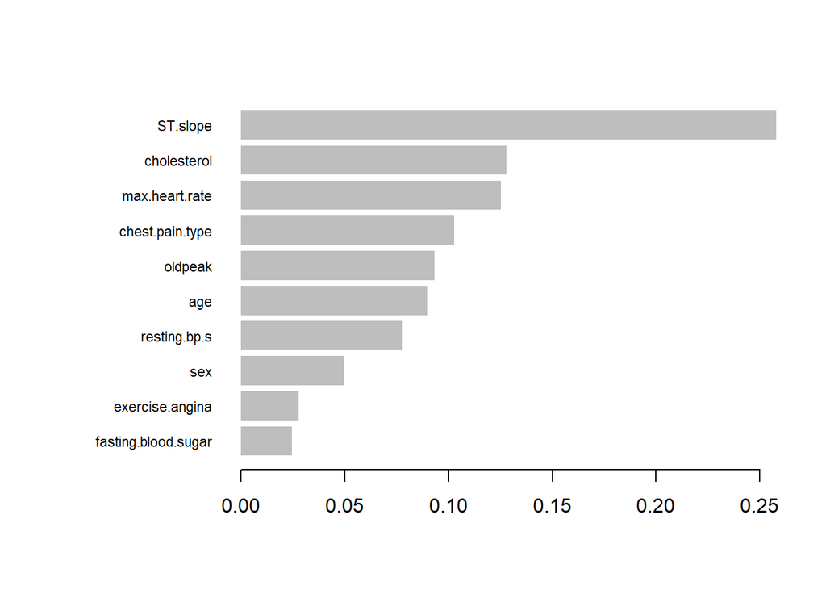

```r
imp_mat <- xgb.importance(model = bst_final)
# Plot importance (top 10 variables)
xgb.plot.importance(imp_mat, top_n = 10)
```

ST.Slope still most important factor. Interestingly, cholesterol is 2nd most important

Method Comparison

```r
roc_xgb = roc(test_dat$target, boost_preds_1)
roc_logit = roc(test_dat$target, logit_preds_1)
roc_tree = roc(test_dat$target, tree_preds_1)
bagg.probs=predict(bag_mod_3,
                 newdata=test_dat,
                 type="prob")

roc_bag = roc(test_dat$target, bagg.probs[,"1"])
```

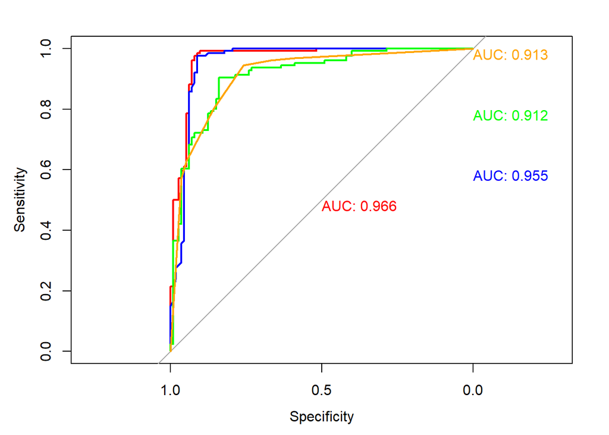

```r
plot.roc(roc_xgb, print.auc = TRUE, col = "red", print.auc.col = "red")

plot.roc(roc_bag , print.auc = TRUE, print.auc.x = 0, print.auc.y = 0.6, col ="blue", print.auc.col = "blue", add = TRUE)

plot.roc(roc_logit , print.auc = TRUE, print.auc.x = 0, print.auc.y = 0.8, col ="green", print.auc.col = "green", add = TRUE)

plot.roc(roc_tree , print.auc = TRUE, print.auc.x = 0, print.auc.y = 1, col ="orange", print.auc.col = "orange", add = TRUE)
```